# Overoptimistic predictions and well-calibrated expectations

# 6 Figures

## 6.1 Chance-Based

### 6.1.1 Prediction

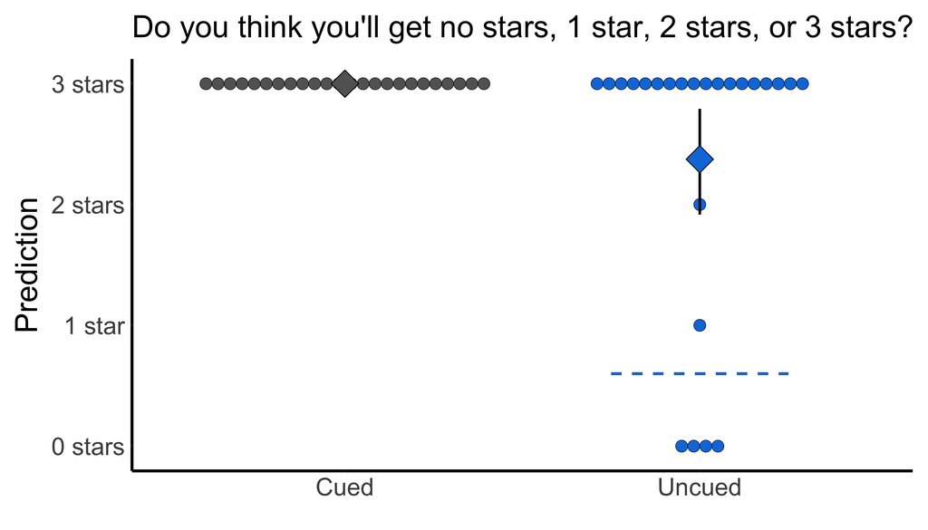

```r
plot.chance_prediction =
  df.chance_analysis %>%
  ggplot(aes(x = condition,
           y = as.numeric(prediction),
           fill = condition,
           group = condition,
           color = condition)) +
  geom_dotplot(binaxis = "y",
               stackdir = "center",
               dotsize = 1,
               binwidth = .1,
               alpha = 1,
               color = "black") +
    geom_segment(
    x = 1.75, xend = 2.25,
    y = 1.6, yend = 1.6,
    linetype = "dashed",
    color = "#0C7BDC",
    linewidth = 2
  ) +
  stat_summary(fun.data = "mean_cl_boot",
           geom = "pointrange",
           size = 4,
           shape = 23,
           fill = plotcolors,
           color = "black",
           linewidth = 2) +
  scale_fill_manual(name = "Condition",
                    labels = c("Cued",
                               "Uncued"),
                    values = plotcolors) +
  scale_color_manual(values = plotcolors,
                     guide = "none") +
  scale_y_continuous(breaks = c(1:4),
                     labels = c("0 stars", "1 star","2 stars", "3 stars")) +
  labs(
       subtitle = "Do you think you'll get no stars, 1 star, 2 stars, or 3 stars?",
       y = "Prediction",
       x = element_blank()) +
  theme_classic(base_size = 50) +
    theme(legend.position = "none",
      axis.ticks.length = unit(0.05, "cm"),
      panel.spacing = unit(0.01, "lines"))

plot.chance_prediction
```

```r
# ggsave((paste0(figures_dir, "chance/chance_prediction.png")),
#        plot = plot.chance_prediction,
#        width = 21, height = 12, device = "png")
```

By age:

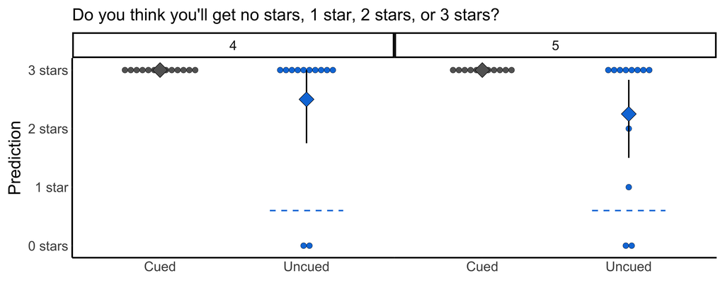

```r
df.chance_analysis %>%
  ggplot(aes(x = condition,
           y = as.numeric(prediction),
           fill = condition,
           group = condition,
           color = condition)) +
  geom_dotplot(binaxis = "y",
               stackdir = "center",
               dotsize = 1,
               binwidth = .1,
               alpha = 1,
               color = "black") +
    geom_segment(
    x = 1.75, xend = 2.25,
    y = 1.6, yend = 1.6,
    linetype = "dashed",
    color = "#0C7BDC",
    linewidth = 2
  ) +
  stat_summary(fun.data = "mean_cl_boot",
           geom = "pointrange",
           size = 4,
           shape = 23,
           color = "black",
           linewidth = 2) +
  scale_fill_manual(name = "Condition",
                    labels = c("Cued",
                               "Uncued"),
                    values = plotcolors) +
  scale_color_manual(values = plotcolors,
                     guide = "none") +
  scale_y_continuous(breaks = c(1:4),
                     labels = c("0 stars", "1 star","2 stars", "3 stars")) +
  labs(
       subtitle = "Do you think you'll get no stars, 1 star, 2 stars, or 3 stars?",
       y = "Prediction",
       x = element_blank()) +
  theme_classic(base_size = 50) +
    theme(legend.position = "none",
      axis.ticks.length = unit(0.05, "cm"),
      panel.spacing = unit(0.01, "lines")) +
  facet_wrap(~age_bin)
```

### 6.1.2 Binary Surprise

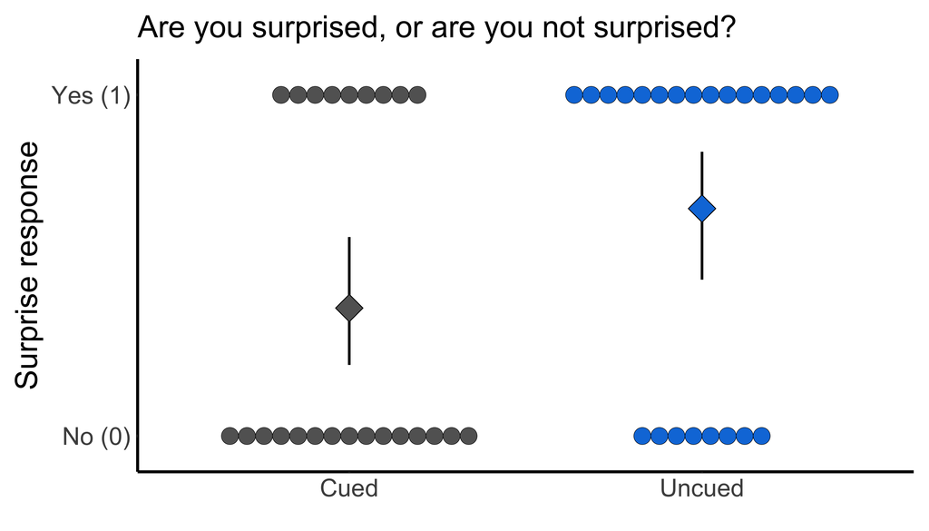

```r
plot.chance_binary =
  df.chance_analysis %>%
  ggplot(aes(x = condition,
           y = as.numeric(surprise_binary),
           fill = condition,
           group = condition,
           color = condition)) +
  stat_summary(fun.data = "mean_cl_boot",
           geom = "pointrange",
           size = 4,
           shape = 23,
           fill = plotcolors,
           color = "black",
           linewidth = 2) +
  geom_dotplot(binaxis = "y",
               stackdir = "center",
               dotsize = .5,
               binwidth = .1,
               color = "black") +
  scale_fill_manual(name = "Condition",
                    labels = c("Cued",
                               "Uncued"),
                    values = plotcolors) +
  scale_color_manual(values = plotcolors,
                     guide = "none") +
  scale_y_continuous(breaks = c(1, 2),
                     labels = c("No (0)","Yes (1)")) +
  labs(
       subtitle = "Are you surprised, or are you not surprised?",
       y = "Surprise response",
       x = element_blank()) +
  theme_classic(base_size = 50) +
  theme(legend.position = "none",
        axis.ticks.length = unit(0.05, "cm"),
        panel.spacing = unit(0.01, "lines"))

plot.chance_binary
```

```r
# ggsave((paste0(figures_dir, "chance/chance_binary_surprise.png")),
#        plot = plot.chance_binary,
#        width = 20, height = 12, device = "png")
```

By age:

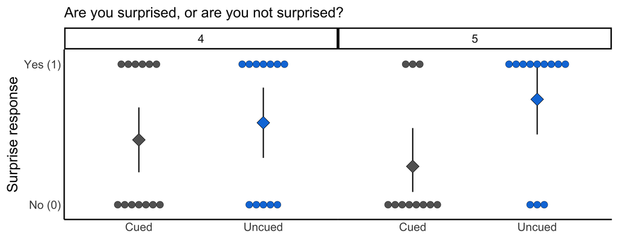

```r
df.chance_analysis %>%
  ggplot(aes(x = condition,
           y = as.numeric(surprise_binary),
           fill = condition,
           group = condition,
           color = condition)) +
  stat_summary(fun.data = "mean_cl_boot",
           geom = "pointrange",
           size = 4,
           shape = 23,
           color = "black",
           linewidth = 2) +
  geom_dotplot(binaxis = "y",
               stackdir = "center",
               dotsize = .5,
               binwidth = .1,
               color = "black") +
  scale_fill_manual(name = "Condition",
                    labels = c("Cued",
                               "Uncued"),
                    values = plotcolors) +
  scale_color_manual(values = plotcolors,
                     guide = "none") +
  scale_y_continuous(breaks = c(1, 2),
                     labels = c("No (0)","Yes (1)")) +
  labs(
       subtitle = "Are you surprised, or are you not surprised?",
       y = "Surprise response",
       x = element_blank()) +
  theme_classic(base_size = 50) +
  theme(legend.position = "none",
        axis.ticks.length = unit(0.05, "cm"),
        panel.spacing = unit(0.01, "lines")) +
    facet_wrap(~age_bin)
```

### 6.1.3 Graded Surprise

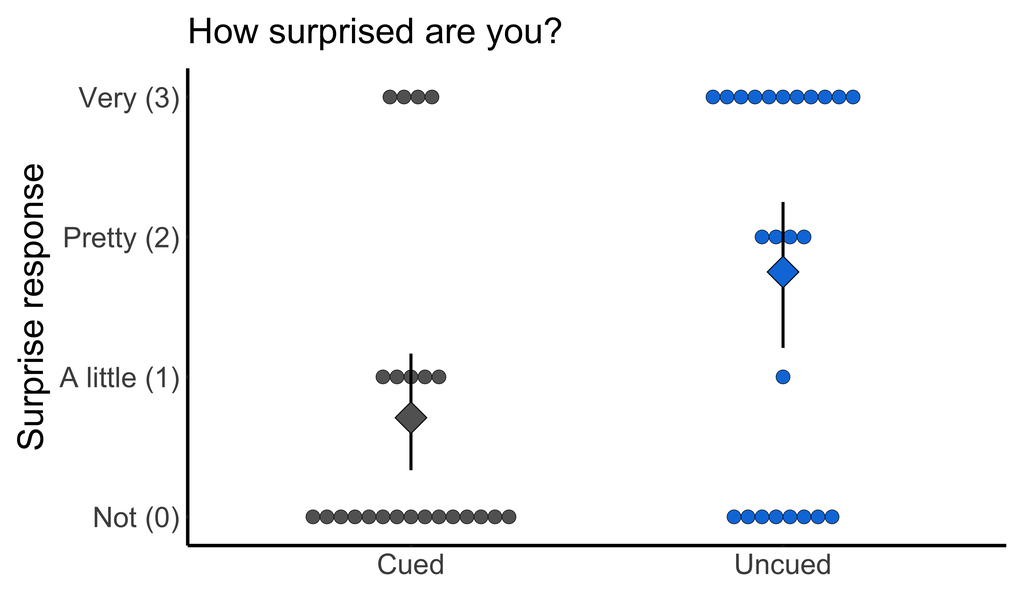

```r
plot.chance_graded =
  df.chance_analysis %>%
  ggplot(aes(x = condition,
           y = as.numeric(surprise_likert),
           fill = condition,
           group = condition,
           color = condition)) +
  geom_dotplot(binaxis = "y",
               stackdir = "center",
               dotsize = 1,
               binwidth = .1,
               alpha = 1,
               color = "black") +
  stat_summary(fun.data = "mean_cl_boot",
           geom = "pointrange",
           size = 4,
           shape = 23,
           fill = plotcolors,
           color = "black",
           linewidth = 2) +
  scale_fill_manual(name = "Condition",
                    labels = c("Cued",
                               "Uncued"),
                    values = plotcolors) +
  scale_color_manual(values = plotcolors,
                     guide = "none") +
  scale_y_continuous(breaks = c(1:4),
                     labels = c("Not (0)", "A little (1)","Pretty (2)", "Very (3)")) +
  labs(
       subtitle = "How surprised are you?",
       y = "Surprise response",
       x = element_blank()) +
  theme_classic(base_size = 50) +
    theme(legend.position = "none",
      axis.ticks.length = unit(0.05, "cm"),
      panel.spacing = unit(0.01, "lines"))

plot.chance_graded
```

```r
# ggsave((paste0(figures_dir, "chance/chance_graded_surprise.png")),
#        plot = plot.chance_graded,
#        width = 20, height = 12, device = "png")
```

By age:

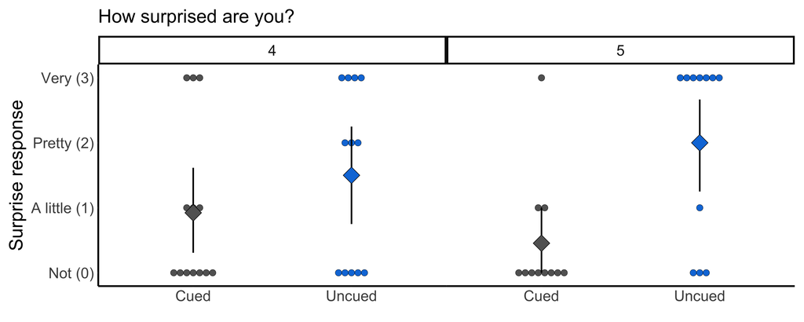

```r
df.chance_analysis %>%
  ggplot(aes(x = condition,
           y = as.numeric(surprise_likert),
           fill = condition,
           group = condition,
           color = condition)) +
  geom_dotplot(binaxis = "y",
               stackdir = "center",
               dotsize = 1,
               binwidth = .1,
               alpha = 1,
               color = "black") +
  stat_summary(fun.data = "mean_cl_boot",
           geom = "pointrange",
           size = 4,
           shape = 23,
           color = "black",
           linewidth = 2) +
  scale_fill_manual(name = "Condition",
                    labels = c("Cued",
                               "Uncued"),
                    values = plotcolors) +
  scale_color_manual(values = plotcolors,
                     guide = "none") +
  scale_y_continuous(breaks = c(1:4),
                     labels = c("Not (0)", "A little (1)","Pretty (2)", "Very (3)")) +
  labs(
       subtitle = "How surprised are you?",
       y = "Surprise response",
       x = element_blank()) +
  theme_classic(base_size = 50) +
    theme(legend.position = "none",
      axis.ticks.length = unit(0.05, "cm"),
      panel.spacing = unit(0.01, "lines")) +
    facet_wrap(~age_bin)
```

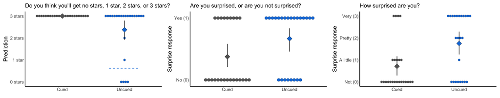

```r
plot.chance_sidebyside =
  plot.chance_prediction +
  plot.chance_binary +
  plot.chance_graded

plot.chance_sidebyside +
  theme(legend.position = "none")
```

## 6.2 Memory

### 6.2.1 Prediction

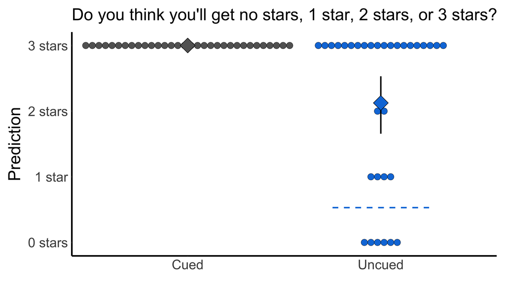

```r
plot.memory_prediction =
  df.memory_analysis %>%
  ggplot(aes(x = condition,
           y = as.numeric(prediction),
           fill = condition,
           group = condition,
           color = condition)) +
  geom_segment(
    x = 1.75, xend = 2.25,
    y = 1.53, yend = 1.53,
    linetype = "dashed",
    color = "#0C7BDC",
    linewidth = 2
  ) +
  geom_dotplot(binaxis = "y",
               stackdir = "center",
               dotsize = 1,
               binwidth = .1,
               alpha = 1,
               color = "black") +
  stat_summary(fun.data = "mean_cl_boot",
           geom = "pointrange",
           size = 4,
           shape = 23,
           fill = plotcolors,
           color = "black",
           linewidth = 2) +
  scale_fill_manual(name = "Condition",
                    labels = c("Cued",
                               "Uncued"),
                    values = plotcolors) +
  scale_color_manual(values = plotcolors,
                     guide = "none") +
  scale_y_continuous(breaks = c(1:4),
                     labels = c("0 stars", "1 star","2 stars", "3 stars")) +
  labs(
       subtitle = "Do you think you'll get no stars, 1 star, 2 stars, or 3 stars?",
       y = "Prediction",
       x = element_blank()) +
  theme_classic(base_size = 50) +
    theme(legend.position = "none",
      axis.ticks.length = unit(0.05, "cm"),
      panel.spacing = unit(0.01, "lines"))

plot.memory_prediction
```

```r
# ggsave((paste0(figures_dir, "memory/memory_prediction.png")),
#        plot = plot.memory_prediction,
#        width = 21, height = 12, device = "png")
```

By age:

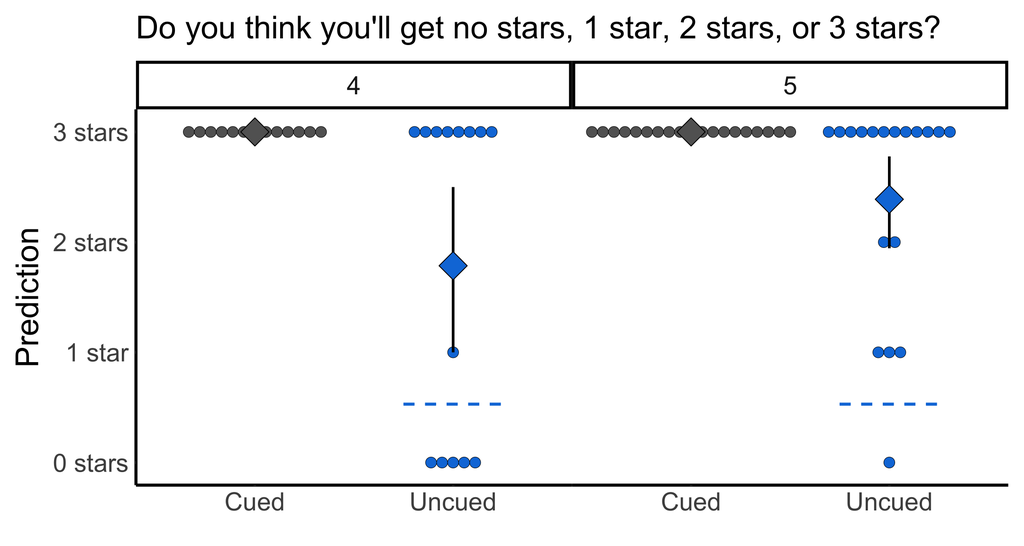

```r
df.memory_analysis %>%
  ggplot(aes(x = condition,
           y = as.numeric(prediction),
           fill = condition,
           group = condition,
           color = condition)) +
  geom_segment(
    x = 1.75, xend = 2.25,
    y = 1.53, yend = 1.53,
    linetype = "dashed",
    color = "#0C7BDC",
    linewidth = 2
  ) +
  geom_dotplot(binaxis = "y",
               stackdir = "center",
               dotsize = 1,
               binwidth = .1,
               alpha = 1,
               color = "black") +
  stat_summary(fun.data = "mean_cl_boot",
           geom = "pointrange",
           size = 4,
           shape = 23,
           color = "black",
           linewidth = 2) +
  scale_fill_manual(name = "Condition",
                    labels = c("Cued",
                               "Uncued"),
                    values = plotcolors) +
  scale_color_manual(values = plotcolors,
                     guide = "none") +
  scale_y_continuous(breaks = c(1:4),
                     labels = c("0 stars", "1 star","2 stars", "3 stars")) +
  labs(
       subtitle = "Do you think you'll get no stars, 1 star, 2 stars, or 3 stars?",
       y = "Prediction",
       x = element_blank()) +
  theme_classic(base_size = 50) +
    theme(legend.position = "none",
      axis.ticks.length = unit(0.05, "cm"),
      panel.spacing = unit(0.01, "lines")) +
  facet_wrap(~age_bin)
```

```r
# ggsave((paste0(figures_dir, "memory/memory_prediction_age.png")),
#        width = 21, height = 12, device = "png")
```

### 6.2.2 Binary Surprise

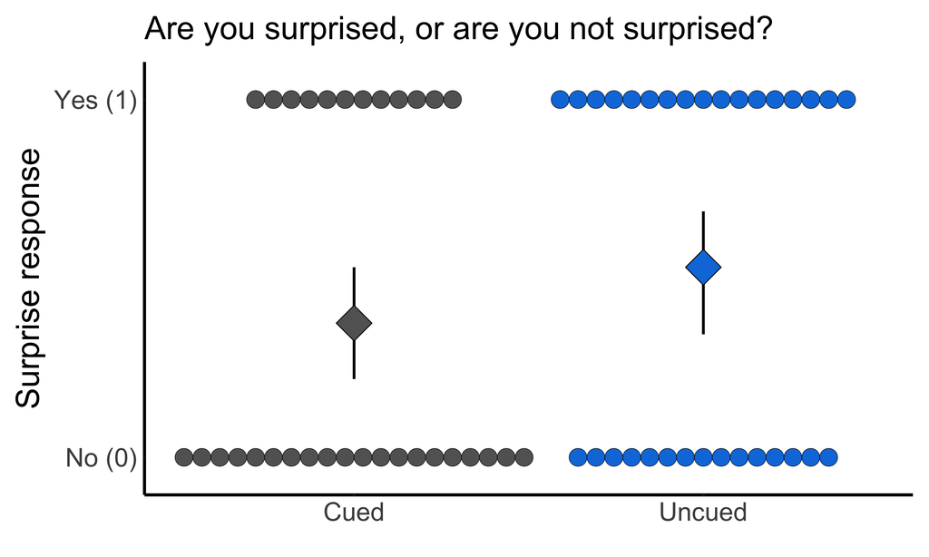

```r
plot.memory_binary =
  df.memory_analysis %>%
  ggplot(aes(x = condition,
           y = as.numeric(surprise_binary),
           fill = condition,
           group = condition,
           color = condition)) +
  stat_summary(fun.data = "mean_cl_boot",
           geom = "pointrange",
           size = 5,
           shape = 23,
           fill = plotcolors,
           color = "black",
           linewidth = 2) +
  geom_dotplot(binaxis = "y",
               stackdir = "center",
               dotsize = .5,
               binwidth = .1,
               color = "black") +
  scale_fill_manual(name = "Condition",
                    labels = c("Cued",
                               "Uncued"),
                    values = plotcolors) +
  scale_color_manual(values = plotcolors,
                     guide = "none") +
  scale_y_continuous(breaks = c(1, 2),
                     labels = c("No (0)","Yes (1)")) +
  labs(
       subtitle = "Are you surprised, or are you not surprised?",
       y = "Surprise response",
       x = element_blank()) +
  theme_classic(base_size = 50) +
  theme(legend.position = "none",
        axis.ticks.length = unit(0.05, "cm"),
        panel.spacing = unit(0.01, "lines"))

plot.memory_binary
```

```r
# ggsave((paste0(figures_dir, "memory/memory_binary_surprise.png")),
#        plot = plot.memory_binary,
#        width = 20, height = 12, device = "png")
```

By age:

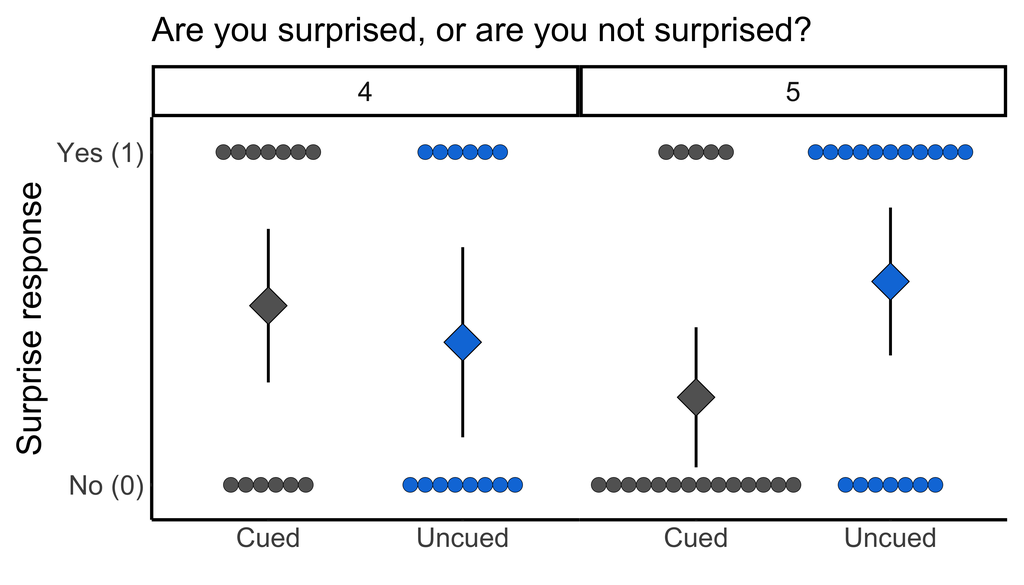

```r
df.memory_analysis %>%
  ggplot(aes(x = condition,
           y = as.numeric(surprise_binary),
           fill = condition,
           group = condition,
           color = condition)) +
  stat_summary(fun.data = "mean_cl_boot",
           geom = "pointrange",
           size = 5,
           shape = 23,
           color = "black",
           linewidth = 2) +
  geom_dotplot(binaxis = "y",
               stackdir = "center",
               dotsize = .45,
               binwidth = .1,
               color = "black") +
  scale_fill_manual(name = "Condition",
                    labels = c("Cued",
                               "Uncued"),
                    values = plotcolors) +
  scale_color_manual(values = plotcolors,
                     guide = "none") +
  scale_y_continuous(breaks = c(1, 2),
                     labels = c("No (0)","Yes (1)")) +
  labs(
       subtitle = "Are you surprised, or are you not surprised?",
       y = "Surprise response",
       x = element_blank()) +
  theme_classic(base_size = 50) +
  theme(legend.position = "none",
        axis.ticks.length = unit(0.05, "cm"),
        panel.spacing = unit(0.01, "lines")) +
  facet_wrap(~age_bin)
```

```r
# ggsave((paste0(figures_dir, "memory/memory_binary_surprise_age.png")),
#        width = 20, height = 12, device = "png")
```

### 6.2.3 Graded Surprise

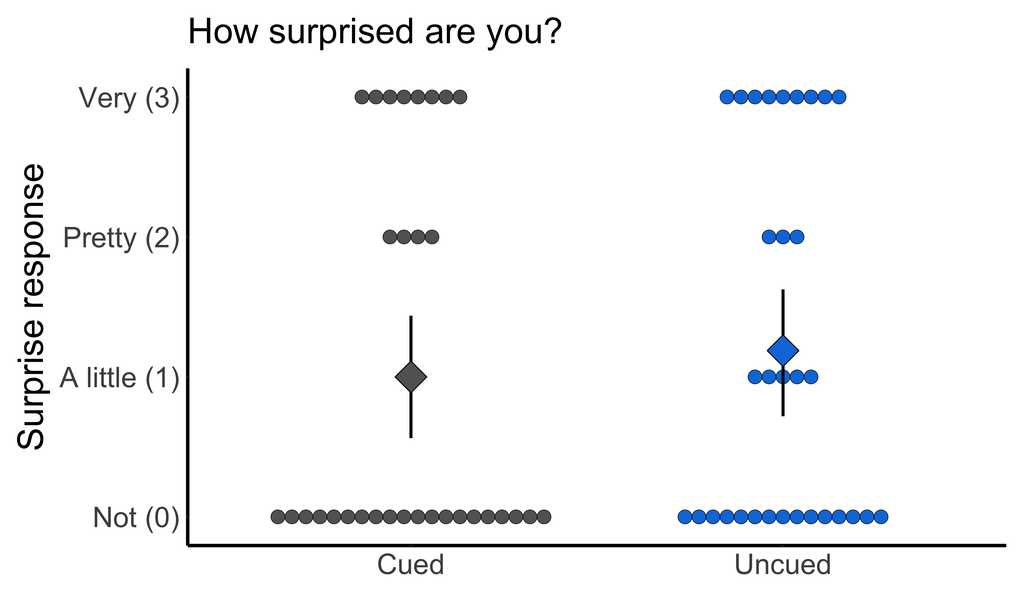

```r
plot.memory_graded =
  df.memory_analysis %>%
  ggplot(aes(x = condition,
           y = as.numeric(surprise_likert),
           fill = condition,
           group = condition,
           color = condition)) +
  geom_dotplot(binaxis = "y",
               stackdir = "center",
               dotsize = 1,
               binwidth = .1,
               alpha = 1,
               color = "black") +
  stat_summary(fun.data = "mean_cl_boot",
           geom = "pointrange",
           size = 4,
           shape = 23,
           fill = plotcolors,
           color = "black",
           linewidth = 2) +
  scale_fill_manual(name = "Condition",
                    labels = c("Cued",
                               "Uncued"),
                    values = plotcolors) +
  scale_color_manual(values = plotcolors,
                     guide = "none") +
  scale_y_continuous(breaks = c(1:4),
                     labels = c("Not (0)", "A little (1)","Pretty (2)", "Very (3)")) +
  labs(
       subtitle = "How surprised are you?",
       y = "Surprise response",
       x = element_blank()) +
  theme_classic(base_size = 50) +
    theme(legend.position = "none",
      axis.ticks.length = unit(0.05, "cm"),
      panel.spacing = unit(0.01, "lines"))

plot.memory_graded
```

```r
# ggsave((paste0(figures_dir, "memory/memory_graded_surprise.png")),
#        plot = plot.memory_graded,
#        width = 20, height = 12, device = "png")
```

By age:

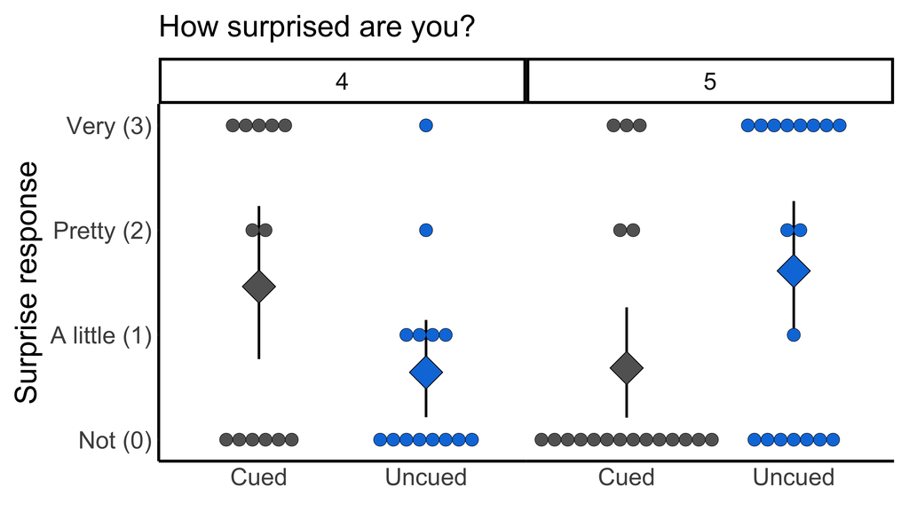

```r
df.memory_analysis %>%
  ggplot(aes(x = condition,
           y = as.numeric(surprise_likert),
           fill = condition,
           group = condition,
           color = condition)) +
  stat_summary(fun.data = "mean_cl_boot",
           geom = "pointrange",
           size = 5,
           shape = 23,
           color = "black",
           linewidth = 2) +
  geom_dotplot(binaxis = "y",
               stackdir = "center",
               dotsize = 1.25,
               binwidth = .1,
               color = "black") +
  scale_fill_manual(name = "Condition",
                    labels = c("Cued",
                               "Uncued"),
                    values = plotcolors) +
  scale_color_manual(values = plotcolors,
                     guide = "none") +
  scale_y_continuous(breaks = c(1:4),
                     labels = c("Not (0)", "A little (1)","Pretty (2)", "Very (3)")) +
  labs(
       subtitle = "How surprised are you?",
       y = "Surprise response",
       x = element_blank()) +
  theme_classic(base_size = 50) +
    theme(legend.position = "none",
      axis.ticks.length = unit(0.05, "cm"),
      panel.spacing = unit(0.01, "lines")) +
  facet_wrap(~age_bin)
```

```r
# ggsave((paste0(figures_dir, "memory/memory_graded_surprise_age.png")),
#        width = 20, height = 12, device = "png")
```

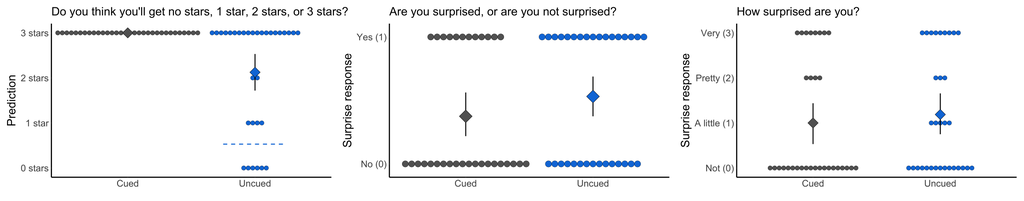

```r
plot.memory_sidebyside =
  plot.memory_prediction +
  plot.memory_binary +
  plot.memory_graded

plot.memory_sidebyside +
  theme(legend.position = "none")
```

# 7 Inferential Statistics

## 7.1 Chance-Based Game

### 7.1.1 Prediction

Table:

```r
df.chance_analysis %>%
  count(condition, prediction)
```

```
## # A tibble: 5 × 3
##   condition prediction     n
##   <fct>     <ord>      <int>
## 1 Cued      3             24
## 2 Uncued    0              4
## 3 Uncued    1              1
## 4 Uncued    2              1
## 5 Uncued    3             18
```

```r
df.chance_analysis %>%
  mutate(prediction_numerical =
           case_when(prediction == "0" ~ 0,
                     prediction == "1" ~ 1,
                     prediction == "2" ~ 2,
                     prediction == "3" ~ 3)) %>%
  group_by(condition) %>%
  summarise(mean = mean(prediction_numerical),
            sd = sd(prediction_numerical))
```

```
## # A tibble: 2 × 3
##   condition  mean    sd
##   <fct>     <dbl> <dbl>
## 1 Cued       3     0
## 2 Uncued     2.38  1.17
```

```r
# The expected value for "Unexpected Success" is .6 because we can approximate each draw’s probability as: \mathbb{P}(\text{sun card}) = \frac{3}{15} = 0.2. Then: \mathbb{E}[X_1] = \mathbb{E}[X_2] = \mathbb{E}[X_3] = 0.2 \Rightarrow \mathbb{E}[X] = 0.2 + 0.2 + 0.2 = \boxed{0.6}

temp =
  df.chance_analysis %>%
  # convert prediction scale values to numeric
  mutate(prediction_numerical =
           case_when(prediction == "0" ~ 0,
                     prediction == "1" ~ 1,
                     prediction == "2" ~ 2,
                     prediction == "3" ~ 3)) %>%
  filter(condition == "Uncued")

# run t-test
t.test(temp$prediction_numerical,
       mu = .6,
       alternative = "two.sided")
```

```
##
##  One Sample t-test
##
## data:  temp$prediction_numerical
## t = 7.4157, df = 23, p-value = 1.536e-07
## alternative hypothesis: true mean is not equal to 0.6
## 95 percent confidence interval:
##  1.879853 2.870147
## sample estimates:
## mean of x
##     2.375
```

Between conditions:

```r
t.test(as.numeric(prediction) ~ condition,
       alternative = "two.sided",
       data = df.chance_analysis)
```

```
##
##  Welch Two Sample t-test
##
## data:  as.numeric(prediction) by condition
## t = 2.6112, df = 23, p-value = 0.01561
## alternative hypothesis: true difference in means between group Cued and group Uncued is not equal to 0
## 95 percent confidence interval:
##  0.1298528 1.1201472
## sample estimates:
##   mean in group Cued mean in group Uncued
##                4.000                3.375
```

### 7.1.2 Surprise vs Chance

Is rate of surprise sig above 50%?

```r
temp =
  df.chance_analysis %>%
  filter(condition == "Uncued") %>%
  mutate(surprise_binary = case_when(surprise_binary == "Surprised" ~ 1,
                                     surprise_binary == "Not surprised" ~ 0))

t.test(as.numeric(temp$surprise_binary),
       mu = .5,
       alternative = "greater")
```

```
##
##  One Sample t-test
##
## data:  as.numeric(temp$surprise_binary)
## t = 1.6956, df = 23, p-value = 0.05173
## alternative hypothesis: true mean is greater than 0.5
## 95 percent confidence interval:
##  0.4982023       Inf
## sample estimates:
## mean of x
## 0.6666667
```

### 7.1.3 Binary Surprise

Table:

```r
df.chance_analysis %>%
  count(condition, surprise_binary)
```

```
## # A tibble: 4 × 3
##   condition surprise_binary     n
##   <fct>     <ord>           <int>
## 1 Cued      Not surprised      15
## 2 Cued      Surprised           9
## 3 Uncued    Not surprised       8
## 4 Uncued    Surprised          16
```

```r
df.chance_analysis %>%
  mutate(surprise_binary_numerical =
           case_when(surprise_binary == "Not surprised" ~ 0,
                     surprise_binary == "Surprised" ~ 1)) %>%
  group_by(condition) %>%
  summarise(mean = mean(surprise_binary_numerical),
            sd = sd(surprise_binary_numerical))
```

```
## # A tibble: 2 × 3
##   condition  mean    sd
##   <fct>     <dbl> <dbl>
## 1 Cued      0.375 0.495
## 2 Uncued    0.667 0.482
```

Regression:

```r
# logistic regression
fit.chance_surprise =
  clm(
    # binary surprise is DV
    surprise_binary ~
      # intercept
      1 +
      # condition as predictor
      condition,
    data = df.chance_analysis)

# print model outputs
fit.chance_surprise %>%
  summary()
```

```
## formula: surprise_binary ~ 1 + condition
## data:    df.chance_analysis
##
##  link  threshold nobs logLik AIC   niter max.grad cond.H
##  logit flexible  48   -31.15 66.31 3(0)  1.15e-08 6.7e+00
##
## Coefficients:
##                 Estimate Std. Error z value Pr(>|z|)
## conditionUncued   1.2040     0.6044   1.992   0.0464 *
## ---
## Signif. codes:  0 '***' 0.001 '**' 0.01 '*' 0.05 '.' 0.1 ' ' 1
##
## Threshold coefficients:
##                         Estimate Std. Error z value
## Not surprised|Surprised   0.5108     0.4216   1.212
```

```r
# plot model predictions
probs.chance_surprise =
  ggpredict(fit.chance_surprise)

probs.chance_surprise
```

```
## $condition
## # Predicted probabilities of surprise_binary
##
## surprise_binary: 1
##
## condition | Predicted |     95% CI
## ----------------------------------
## Cued      |      0.62 | 0.42, 0.79
## Uncued    |      0.33 | 0.18, 0.54
##
## surprise_binary: 2
##
## condition | Predicted |     95% CI
## ----------------------------------
## Cued      |      0.38 | 0.21, 0.58
## Uncued    |      0.67 | 0.46, 0.82
##
##
## attr(,"class")
## [1] "ggalleffects" "list"
## attr(,"model.name")
## [1] "fit.chance_surprise"
```

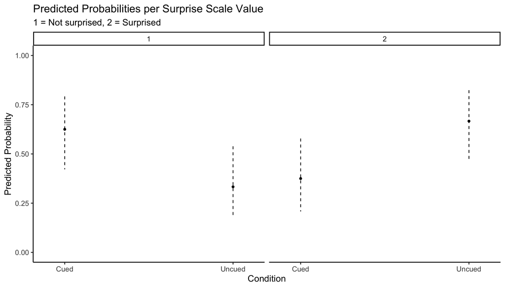

```r
plot(probs.chance_surprise) +
  ylim(0, 1) +
  labs(title = "Predicted Probabilities per Surprise Scale Value",
       subtitle = "1 = Not surprised, 2 = Surprised",
       x = "Condition",
       y = "Predicted Probability") +
  theme_classic(base_size = 18)
```

Checking for age interaction:

```r
# logistic regression
fit.chance_surprise =
  clm(
    # binary surprise is DV
    surprise_binary ~
      # intercept
      1 +
      # condition as predictor
      condition * age_bin,
    data = df.chance_analysis)

# print model outputs
fit.chance_surprise %>%
  summary()
```

```
## formula: surprise_binary ~ 1 + condition * age_bin
## data:    df.chance_analysis
##
##  link  threshold nobs logLik AIC   niter max.grad cond.H
##  logit flexible  48   -30.32 68.63 4(0)  4.70e-12 1.2e+04
##
## Coefficients:
##                         Estimate Std. Error z value Pr(>|z|)
## conditionUncued          -5.8647     5.5456  -1.058    0.290
## age_bin                  -0.8267     0.8763  -0.943    0.345
## conditionUncued:age_bin   1.5888     1.2471   1.274    0.203
##
## Threshold coefficients:
##                         Estimate Std. Error z value
## Not surprised|Surprised   -3.153      3.882  -0.812
```

Wilcox:

```r
wilcox.test(as.numeric(surprise_binary) ~ condition,
            data = df.chance_analysis)
```

```
##
##  Wilcoxon rank sum test with continuity correction
##
## data:  as.numeric(surprise_binary) by condition
## W = 204, p-value = 0.04666
## alternative hypothesis: true location shift is not equal to 0
```

### 7.1.4 Graded Surprise

Table:

```r
df.chance_analysis %>%
  count(condition, surprise_likert)
```

```
## # A tibble: 7 × 3
##   condition surprise_likert        n
##   <fct>     <ord>              <int>
## 1 Cued      Not surprised         15
## 2 Cued      A little surprised     5
## 3 Cued      Very surprised         4
## 4 Uncued    Not surprised          8
## 5 Uncued    A little surprised     1
## 6 Uncued    Pretty surprised       4
## 7 Uncued    Very surprised        11
```

```r
df.chance_analysis %>%
  mutate(surprise_likert_numerical =
           case_when(surprise_likert == "Not surprised" ~ 0,
                     surprise_likert == "A little surprised" ~ 1,
                     surprise_likert == "Pretty surprised" ~ 2,
                     surprise_likert == "Very surprised" ~ 3)) %>%
  group_by(condition) %>%
  summarise(mean = mean(surprise_likert_numerical),
            sd = sd(surprise_likert_numerical))
```

```
## # A tibble: 2 × 3
##   condition  mean    sd
##   <fct>     <dbl> <dbl>
## 1 Cued      0.708  1.12
## 2 Uncued    1.75   1.36
```

Regression:

```r
# logistic regression
fit.chance_surprise_graded =
  clm(
    # graded surprise is DV
    surprise_likert ~
      # intercept
      1 +
      # condition as predictor
      condition,
    data = df.chance_analysis)

# print model outputs
fit.chance_surprise_graded %>%
  summary()
```

```
## formula: surprise_likert ~ 1 + condition
## data:    df.chance_analysis
##
##  link  threshold nobs logLik AIC    niter max.grad cond.H
##  logit flexible  48   -53.50 115.00 5(1)  1.31e-11 4.6e+01
##
## Coefficients:
##                 Estimate Std. Error z value Pr(>|z|)
## conditionUncued   1.4366     0.5753   2.497   0.0125 *
## ---
## Signif. codes:  0 '***' 0.001 '**' 0.01 '*' 0.05 '.' 0.1 ' ' 1
##
## Threshold coefficients:
##                                     Estimate Std. Error z value
## Not surprised|A little surprised      0.5858     0.4105   1.427
## A little surprised|Pretty surprised   1.1760     0.4429   2.655
## Pretty surprised|Very surprised       1.6052     0.4754   3.376
```

```r
# plot model predictions
probs.chance_surprise_graded =
  ggpredict(fit.chance_surprise_graded)

probs.chance_surprise_graded
```

```
## $condition
## # Predicted probabilities of surprise_likert
##
## surprise_likert: 1
##
## condition | Predicted |     95% CI
## ----------------------------------
## Cued      |      0.64 | 0.45, 0.80
## Uncued    |      0.30 | 0.16, 0.50
##
## surprise_likert: 2
##
## condition | Predicted |     95% CI
## ----------------------------------
## Cued      |      0.12 | 0.05, 0.25
## Uncued    |      0.14 | 0.06, 0.27
##
## surprise_likert: 3
##
## condition | Predicted |     95% CI
## ----------------------------------
## Cued      |      0.07 | 0.02, 0.18
## Uncued    |      0.11 | 0.04, 0.25
##
## surprise_likert: 4
##
## condition | Predicted |     95% CI
## ----------------------------------
## Cued      |      0.17 | 0.07, 0.34
## Uncued    |      0.46 | 0.28, 0.65
##
##
## attr(,"class")
## [1] "ggalleffects" "list"
## attr(,"model.name")
## [1] "fit.chance_surprise_graded"
```

Checking for age interaction:

```r
# logistic regression
fit.chance_surprise =
  clm(
    # binary surprise is DV
    surprise_likert ~
      # intercept
      1 +
      # condition as predictor
      condition * age_bin,
    data = df.chance_analysis)

# print model outputs
fit.chance_surprise %>%
  summary()
```

```
## formula: surprise_likert ~ 1 + condition * age_bin
## data:    df.chance_analysis
##
##  link  threshold nobs logLik AIC    niter max.grad cond.H
##  logit flexible  48   -52.42 116.84 5(1)  9.39e-12 2.1e+04
##
## Coefficients:
##                         Estimate Std. Error z value Pr(>|z|)
## conditionUncued          -5.9686     5.1238  -1.165    0.244
## age_bin                  -0.8326     0.8472  -0.983    0.326
## conditionUncued:age_bin   1.6668     1.1533   1.445    0.148
##
## Threshold coefficients:
##                                     Estimate Std. Error z value
## Not surprised|A little surprised      -3.103      3.743  -0.829
## A little surprised|Pretty surprised   -2.499      3.737  -0.669
## Pretty surprised|Very surprised       -2.057      3.736  -0.551
```

Wilcox:

```r
wilcox.test(as.numeric(surprise_likert) ~ condition,
            data = df.chance_analysis)
```

```
##
##  Wilcoxon rank sum test with continuity correction
##
## data:  as.numeric(surprise_likert) by condition
## W = 176.5, p-value = 0.01344
## alternative hypothesis: true location shift is not equal to 0
```

### 7.1.5 Robustness Tests

Correlation:

```r
cor.test(as.numeric(df.chance_analysis$prediction),
         as.numeric(df.chance_analysis$surprise_likert),
         method = "spearman")
```

```
##
##  Spearman's rank correlation rho
##
## data:  as.numeric(df.chance_analysis$prediction) and as.numeric(df.chance_analysis$surprise_likert)
## S = 21139, p-value = 0.3175
## alternative hypothesis: true rho is not equal to 0
## sample estimates:
##        rho
## -0.1473857
```

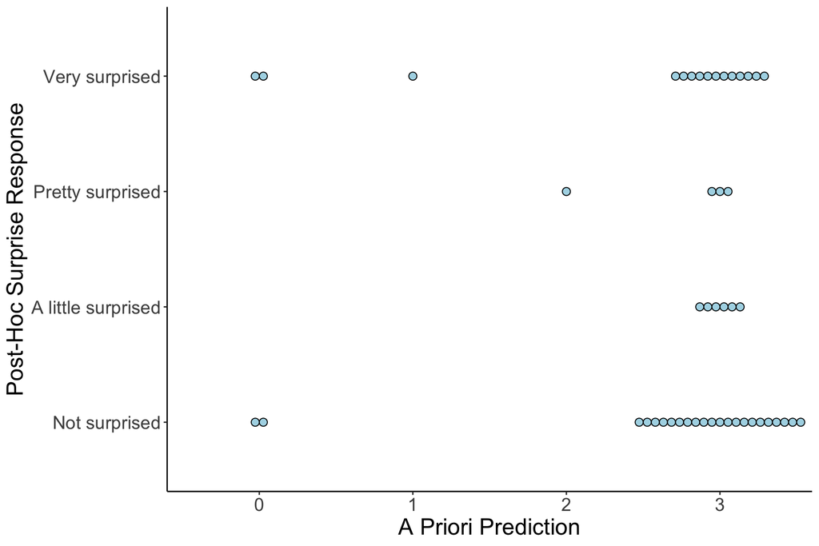

```r
plot.correlation =
  df.chance_analysis %>%
  ggplot(aes(x = prediction,
             y = surprise_likert)) +
  geom_dotplot(dotsize = .7,
               binaxis = "y",
               stackdir = "center",
               stackratio = 1,
               color = "black",
               fill = "lightblue") +
  # geom_point(size = 3,
  #            color = "black",
  #            position = position_jitter(width = .075,
  #                                       height = 0),
  #            alpha = .2) +
  labs(x = "A Priori Prediction",
       y = "Post-Hoc Surprise Response")

plot.correlation
```

```r
# ggsave((paste0(figures_dir, "chance/chance_correlation.png")),
#        plot = plot.correlation,
#        width = 9, height = 6, device = "png")
```

Subsetting for children who predicted 3 stars:

```r
df.robust_chance =
  df.chance_analysis %>%
  filter(prediction == 3)
```

```r
# logistic regression
fit.chance_surprise =
  clm(
    # binary surprise is DV
    surprise_likert ~
      # intercept
      1 +
      # condition as predictor
      condition,
    data = df.robust_chance)

# print model outputs
fit.chance_surprise %>%
  summary()
```

```
## formula: surprise_likert ~ 1 + condition
## data:    df.robust_chance
##
##  link  threshold nobs logLik AIC    niter max.grad cond.H
##  logit flexible  42   -46.42 100.84 5(1)  2.03e-10 4.2e+01
##
## Coefficients:
##                 Estimate Std. Error z value Pr(>|z|)
## conditionUncued   1.4214     0.6181     2.3   0.0215 *
## ---
## Signif. codes:  0 '***' 0.001 '**' 0.01 '*' 0.05 '.' 0.1 ' ' 1
##
## Threshold coefficients:
##                                     Estimate Std. Error z value
## Not surprised|A little surprised      0.5683     0.4121   1.379
## A little surprised|Pretty surprised   1.2499     0.4552   2.746
## Pretty surprised|Very surprised       1.6330     0.4888   3.341
```

```r
# logistic regression
fit.chance_surprise =
  clm(
    # binary surprise is DV
    surprise_binary ~
      # intercept
      1 +
      # condition as predictor
      condition,
    data = df.robust_chance)

# print model outputs
fit.chance_surprise %>%
  summary()
```

```
## formula: surprise_binary ~ 1 + condition
## data:    df.robust_chance
##
##  link  threshold nobs logLik AIC   niter max.grad cond.H
##  logit flexible  42   -27.33 58.67 3(0)  8.63e-09 6.1e+00
##
## Coefficients:
##                 Estimate Std. Error z value Pr(>|z|)
## conditionUncued    1.204      0.654   1.841   0.0657 .
## ---
## Signif. codes:  0 '***' 0.001 '**' 0.01 '*' 0.05 '.' 0.1 ' ' 1
##
## Threshold coefficients:
##                         Estimate Std. Error z value
## Not surprised|Surprised   0.5108     0.4216   1.212
```

## 7.2 Memory Game

### 7.2.1 Manhattan Distance

Visualization of what Manhattan distance means:

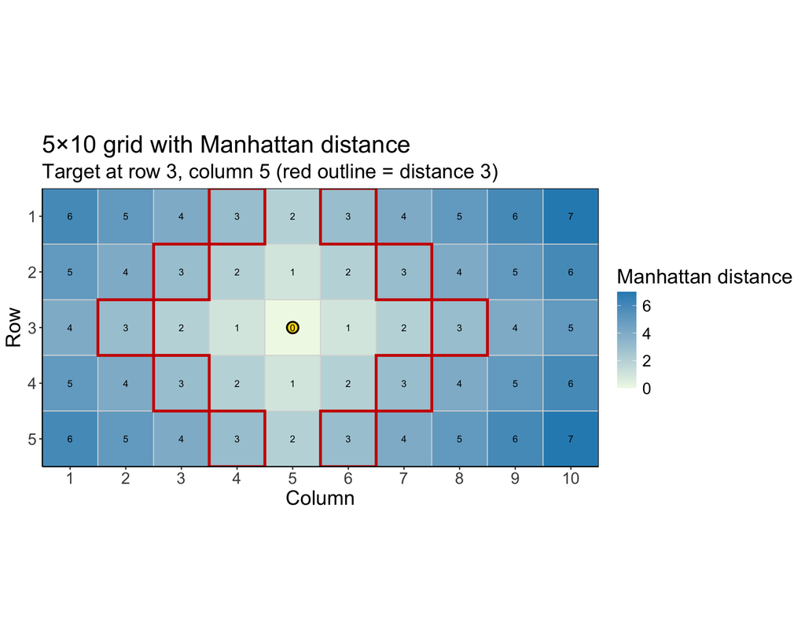

```r
draw_manhattan =
  function(n_rows = 5,
           n_cols = 10,
           target_row = 3,
           target_col = 5,
           highlight_dist = 3) {
    grid = expand.grid(row = 1:n_rows, col = 1:n_cols) %>%
      mutate(dist = abs(row - target_row) + abs(col - target_col),
             highlight = dist == highlight_dist)

    ggplot(grid, aes(x = col, y = row)) +
      geom_tile(aes(fill = dist), color = "grey85", size = 0.4) +
      geom_tile(data = dplyr::filter(grid, highlight),
                fill = NA, color = "red3", size = 1.2) +
      geom_point(data = data.frame(row = target_row, col = target_col),
                 aes(x = col, y = row), inherit.aes = FALSE,
                 shape = 21, size = 4,
                 fill = "gold", color = "black", stroke = 1.2) +
      geom_text(aes(label = dist), size = 3) +
      scale_fill_gradient(low = "#f0f9e8", high = "#2b8cbe",
                          name = "Manhattan distance") +
      coord_fixed(expand = FALSE) +
      scale_x_continuous(breaks = 1:n_cols, minor_breaks = NULL) +
      scale_y_reverse(breaks = 1:n_rows, minor_breaks = NULL) +
      labs(x = "Column", y = "Row",
           title = paste0(n_rows, "×",
                          n_cols,
                          " grid with Manhattan distance"),
           subtitle = paste0("Target at row ", target_row, ", column ", target_col, " (red outline = distance ", highlight_dist, ")")) +
      theme(legend.position = "right",
            panel.border = element_rect(color = "black", fill = NA))
    }

# plot with 5x10 grid
draw_manhattan(5, 10,
               target_row = 3,
               target_col = 5,
               highlight_dist = 3)
```

```r
df.memory_analysis =
  df.memory_analysis %>%
  # compute mean value
  mutate(mean_manhattan_distance =
           case_when(condition == "Uncued" ~
                       (first_choice_dist +
                          second_choice_dist +
                          third_choice_dist)/3,
                     condition == "unsurprising" ~ NA))
```

Performance across trials:

```r
df.memory_analysis %>%
  filter(condition == "Uncued") %>%
  count(n_star_cards_selected)
```

```
## # A tibble: 3 × 2
##   n_star_cards_selected     n
##                   <dbl> <int>
## 1                     0    16
## 2                     1    14
## 3                     2     2
```

```r
df.memory_analysis %>%
  filter(condition == "Uncued") %>%
  count(first_choice_dist)
```

```
## # A tibble: 5 × 2
##   first_choice_dist     n
##               <dbl> <int>
## 1                 0     8
## 2                 1    12
## 3                 2     6
## 4                 3     4
## 5                 4     2
```

```r
df.memory_analysis %>%
  filter(condition == "Uncued") %>%
  count(second_choice_dist)
```

```
## # A tibble: 4 × 2
##   second_choice_dist     n
##                <dbl> <int>
## 1                  0     6
## 2                  1    14
## 3                  2    10
## 4                  3     2
```

```r
df.memory_analysis %>%
  filter(condition == "Uncued") %>%
  count(third_choice_dist)
```

```
## # A tibble: 4 × 2
##   third_choice_dist     n
##               <dbl> <int>
## 1                 0     4
## 2                 1    12
## 3                 2    10
## 4                 3     6
```

```r
df.memory_analysis %>%
  filter(condition == "Uncued") %>%
  summarise(avg_manhattan_distance = mean(mean_manhattan_distance),
            sd_avg_manhattan_distance = sd(mean_manhattan_distance),
            avg_first_choice_dist = mean(first_choice_dist),
            avg_second_choice_dist = mean(second_choice_dist),
            avg_third_choice_dist = mean(third_choice_dist))
```

```
## # A tibble: 1 × 5
##   avg_manhattan_distance sd_avg_manhattan_dist…¹ avg_first_choice_dist
##                    <dbl>                   <dbl>                 <dbl>
## 1                   1.40                   0.653                  1.38
## # ℹ abbreviated name: ¹sd_avg_manhattan_distance
## # ℹ 2 more variables: avg_second_choice_dist <dbl>,
## #   avg_third_choice_dist <dbl>
```

Performance by trial:

```r
df.distance =
  df.memory_analysis %>%
  pivot_longer(cols = ends_with("_dist"),
               names_to = "choice",
               values_to = "distance") %>%
  mutate(choice = factor(choice,
                         levels = c("first_choice_dist",
                                    "second_choice_dist",
                                    "third_choice_dist"),
                         labels = c("First Trial",
                                    "Second Trial",
                                    "Third Trial")))
```

```r
df.distance %>%
  filter(condition == "Uncued") %>%
  group_by(choice) %>%
  summarise(mean = mean(distance, na.rm = T),
            sd = sd(distance, na.rm = T))
```

```
## # A tibble: 3 × 3
##   choice        mean    sd
##   <fct>        <dbl> <dbl>
## 1 First Trial   1.38 1.18
## 2 Second Trial  1.25 0.842
## 3 Third Trial   1.56 0.948
```

```r
summary(lm(distance ~ choice, data = df.distance %>%  filter(condition == "Uncued")))
```

```
##
## Call:
## lm(formula = distance ~ choice, data = df.distance %>% filter(condition ==
##     "Uncued"))
##
## Residuals:
##     Min      1Q  Median      3Q     Max
## -1.5625 -0.5625 -0.2500  0.6562  2.6250
##
## Coefficients:
##                    Estimate Std. Error t value Pr(>|t|)
## (Intercept)          1.3750     0.1771   7.763 1.06e-11 ***
## choiceSecond Trial  -0.1250     0.2505  -0.499    0.619
## choiceThird Trial    0.1875     0.2505   0.748    0.456
## ---
## Signif. codes:  0 '***' 0.001 '**' 0.01 '*' 0.05 '.' 0.1 ' ' 1
##
## Residual standard error: 1.002 on 93 degrees of freedom
## Multiple R-squared:  0.01667,    Adjusted R-squared:  -0.004473
## F-statistic: 0.7885 on 2 and 93 DF,  p-value: 0.4575
```

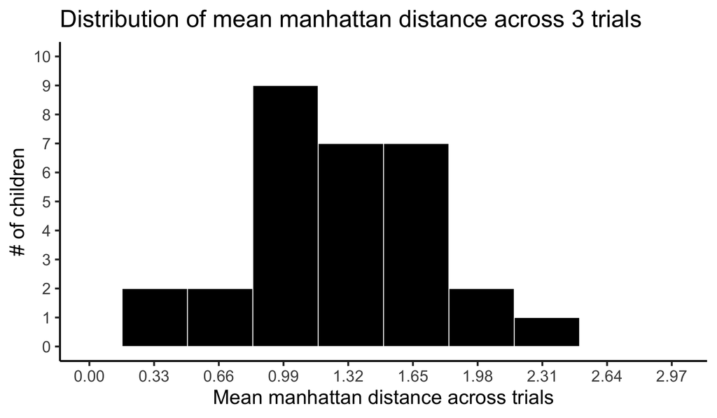

```r
ggplot(df.memory_analysis,
       aes(x = mean_manhattan_distance)) +
  geom_histogram(color = "white", bins = 10,
                 fill = "black") +
  labs(x = "Mean manhattan distance across trials",
       y = "# of children",
       title = "Distribution of mean manhattan distance across 3 trials") +
  scale_x_continuous(limits = c(0, 3),
                     breaks = seq(0, 3, by = 0.33)) +
  scale_y_continuous(limits = c(0, 10),
                     breaks = c(seq(0, 10, 1))) +
  theme_classic(base_size = 24)
```

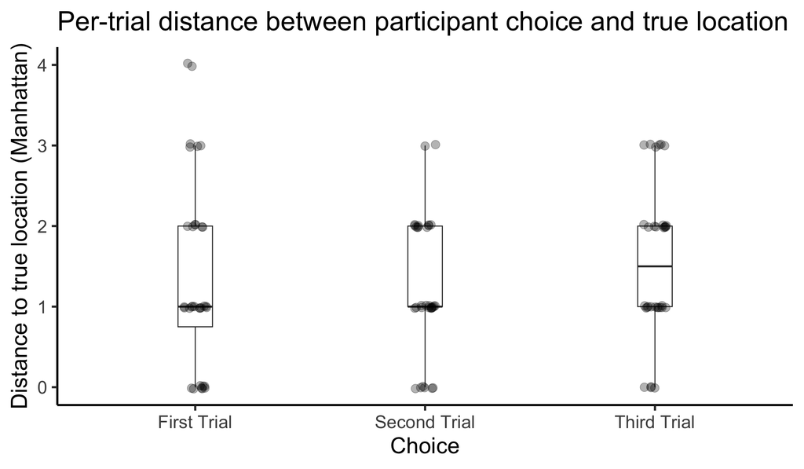

```r
df.distance %>%
  filter(condition == "Uncued") %>%
  ggplot(aes(x = choice, y = distance)) +
  geom_boxplot(width = .15, outlier.shape = NA) +
  geom_jitter(width = .05, height = .02, alpha = .3, size = 4) +
  labs(x = "Choice", y = "Distance to true location (Manhattan)",
       title = "Per-trial distance between participant choice and true location") +
  theme_classic(base_size = 24)
```

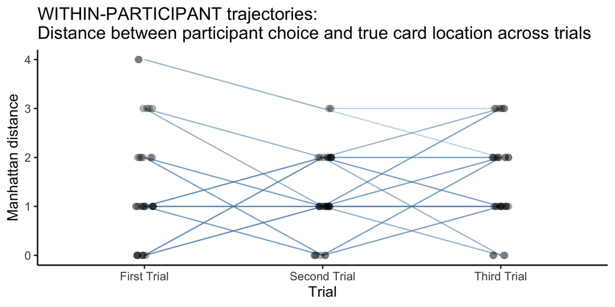

```r
df.distance %>%
  filter(condition == "Uncued") %>%
  ggplot(aes(x = choice, y = distance,
             group = subject_id)) +
  geom_line(alpha = 0.3, size = 1, color = "steelblue") +
  geom_jitter(height = 0, width = .05, alpha = 0.3, size = 5) +
  labs(x = "Trial", y = "Manhattan distance",
       title = "WITHIN-PARTICIPANT trajectories:\nDistance between participant choice and true card location across trials") +
    theme_classic(base_size = 24)
```

In “Unexpected Success”, does Manhattan Distance negatively correlate with surprise so that card picks closer to true locations lead to lower levels of reported surprise?

```r
temp =
  df.memory_analysis %>%
  filter(condition == "Uncued")

summary(clm(surprise_binary ~ 1 + mean_manhattan_distance,
            data = temp))
```

```
## formula: surprise_binary ~ 1 + mean_manhattan_distance
## data:    temp
##
##  link  threshold nobs logLik AIC   niter max.grad cond.H
##  logit flexible  32   -20.69 45.39 4(0)  9.48e-10 3.0e+01
##
## Coefficients:
##                         Estimate Std. Error z value Pr(>|z|)
## mean_manhattan_distance   1.0492     0.6902    1.52    0.128
##
## Threshold coefficients:
##                         Estimate Std. Error z value
## Not surprised|Surprised   1.3072     0.9883   1.323
```

```r
summary(clm(surprise_likert ~ 1 + mean_manhattan_distance,
            data = temp))
```

```
## formula: surprise_likert ~ 1 + mean_manhattan_distance
## data:    temp
##
##  link  threshold nobs logLik AIC   niter max.grad cond.H
##  logit flexible  32   -38.94 85.89 5(1)  5.99e-11 9.0e+01
##
## Coefficients:
##                         Estimate Std. Error z value Pr(>|z|)
## mean_manhattan_distance   0.3080     0.4668    0.66    0.509
##
## Threshold coefficients:
##                                     Estimate Std. Error z value
## Not surprised|A little surprised      0.3321     0.7783   0.427
## A little surprised|Pretty surprised   0.9757     0.7950   1.227
## Pretty surprised|Very surprised       1.3966     0.8001   1.746
```

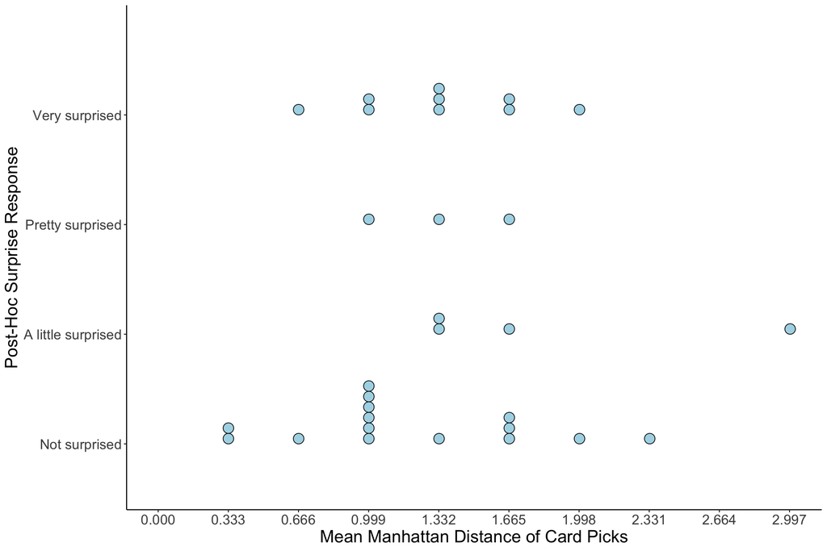

```r
plot.correlation =
  temp %>%
  ggplot(aes(x = mean_manhattan_distance,
             y = surprise_likert)) +
  geom_dotplot(dotsize = .5,
               binaxis = "x",
               stackratio = 1,
               color = "black",
               fill = "lightblue") +
  scale_x_continuous(limits = c(0, 3),
                     breaks = c(seq(0, 3, .333))) +
  labs(x = "Mean Manhattan Distance of Card Picks",
       y = "Post-Hoc Surprise Response")

plot.correlation
```

```r
# ggsave((paste0(figures_dir, "memory/distance_correlation.png")),
#        plot = plot.correlation,
#        width = 12, height = 8, device = "png")
```

### 7.2.2 Prediction

Table:

```r
df.memory_analysis %>%
  count(condition, prediction)
```

```
## # A tibble: 5 × 3
##   condition prediction     n
##   <fct>     <ord>      <int>
## 1 Cued      3             32
## 2 Uncued    0              6
## 3 Uncued    1              4
## 4 Uncued    2              2
## 5 Uncued    3             20
```

```r
df.memory_analysis %>%
  mutate(prediction_numerical =
           case_when(prediction == "0" ~ 0,
                     prediction == "1" ~ 1,
                     prediction == "2" ~ 2,
                     prediction == "3" ~ 3)) %>%
  group_by(condition) %>%
  summarise(mean = mean(prediction_numerical),
            sd = sd(prediction_numerical))
```

```
## # A tibble: 2 × 3
##   condition  mean    sd
##   <fct>     <dbl> <dbl>
## 1 Cued       3     0
## 2 Uncued     2.12  1.24
```

True performance:

```r
df.memory_analysis %>%
  count(condition, n_star_cards_selected)
```

```
## # A tibble: 4 × 3
##   condition n_star_cards_selected     n
##   <fct>                     <dbl> <int>
## 1 Cued                          3    32
## 2 Uncued                        0    16
## 3 Uncued                        1    14
## 4 Uncued                        2     2
```

```r
df.memory_analysis %>%
  group_by(condition) %>%
  summarise(mean = mean(n_star_cards_selected),
            median = median(n_star_cards_selected),
            sd = sd(n_star_cards_selected))
```

```
## # A tibble: 2 × 4
##   condition  mean median    sd
##   <fct>     <dbl>  <dbl> <dbl>
## 1 Cued      3        3   0
## 2 Uncued    0.562    0.5 0.619
```

Between conditions:

```r
t.test(as.numeric(prediction) ~ condition,
       alternative = "two.sided",
       data = df.memory_analysis)
```

```
##
##  Welch Two Sample t-test
##
## data:  as.numeric(prediction) by condition
## t = 3.9987, df = 31, p-value = 0.0003666
## alternative hypothesis: true difference in means between group Cued and group Uncued is not equal to 0
## 95 percent confidence interval:
##  0.4287096 1.3212904
## sample estimates:
##   mean in group Cued mean in group Uncued
##                4.000                3.125
```

Comparison:

```r
# Children's true performance is .56.

temp =
  df.memory_analysis %>%
  # convert prediction scale values to numeric
  mutate(prediction_numerical =
           case_when(prediction == "0" ~ 0,
                     prediction == "1" ~ 1,
                     prediction == "2" ~ 2,
                     prediction == "3" ~ 3)) %>%
  filter(condition == "Uncued")

# run t-test
t.test(temp$prediction_numerical,
       mu = mean(temp$n_star_cards_selected),
       alternative = "two.sided")
```

```
##
##  One Sample t-test
##
## data:  temp$prediction_numerical
## t = 7.1405, df = 31, p-value = 5.027e-08
## alternative hypothesis: true mean is not equal to 0.5625
## 95 percent confidence interval:
##  1.67871 2.57129
## sample estimates:
## mean of x
##     2.125
```

### 7.2.3 Surprise vs Chance

```r
temp =
  df.memory_analysis %>%
  filter(condition == "Uncued") %>%
  mutate(surprise_binary = case_when(surprise_binary == "Surprised" ~ 1,
                                     surprise_binary == "Not surprised" ~ 0))

t.test(as.numeric(temp$surprise_binary),
       mu = .5,
       alternative = "greater")
```

```
##
##  One Sample t-test
##
## data:  as.numeric(temp$surprise_binary)
## t = 0.34867, df = 31, p-value = 0.3648
## alternative hypothesis: true mean is greater than 0.5
## 95 percent confidence interval:
##  0.3792856       Inf
## sample estimates:
## mean of x
##   0.53125
```

### 7.2.4 Binary Surprise

Table:

```r
df.memory_analysis %>%
  count(condition, surprise_binary)
```

```
## # A tibble: 4 × 3
##   condition surprise_binary     n
##   <fct>     <ord>           <int>
## 1 Cued      Not surprised      20
## 2 Cued      Surprised          12
## 3 Uncued    Not surprised      15
## 4 Uncued    Surprised          17
```

```r
df.memory_analysis %>%
  mutate(surprise_binary_numerical =
           case_when(surprise_binary == "Not surprised" ~ 0,
                     surprise_binary == "Surprised" ~ 1)) %>%
  group_by(condition) %>%
  summarise(mean = mean(surprise_binary_numerical),
            sd = sd(surprise_binary_numerical))
```

```
## # A tibble: 2 × 3
##   condition  mean    sd
##   <fct>     <dbl> <dbl>
## 1 Cued      0.375 0.492
## 2 Uncued    0.531 0.507
```

Regression:

```r
# logistic regression
fit.memory_surprise =
  clm(
    # binary surprise is DV
    surprise_binary ~
      # intercept
      1 +
      # condition as predictor
      condition,
      # control for true performance
      # n_star_cards_selected,
    data = df.memory_analysis)

# print model outputs
fit.memory_surprise %>%
  summary()
```

```
## formula: surprise_binary ~ 1 + condition
## data:    df.memory_analysis
##
##  link  threshold nobs logLik AIC   niter max.grad cond.H
##  logit flexible  64   -43.29 90.58 3(0)  1.95e-10 7.0e+00
##
## Coefficients:
##                 Estimate Std. Error z value Pr(>|z|)
## conditionUncued   0.6360     0.5087    1.25    0.211
##
## Threshold coefficients:
##                         Estimate Std. Error z value
## Not surprised|Surprised   0.5108     0.3651   1.399
```

```r
# plot model predictions
probs.memory_surprise =
  ggpredict(fit.memory_surprise)

probs.memory_surprise
```

```
## $condition
## # Predicted probabilities of surprise_binary
##
## surprise_binary: 1
##
## condition | Predicted |     95% CI
## ----------------------------------
## Cued      |      0.62 | 0.45, 0.77
## Uncued    |      0.47 | 0.31, 0.64
##
## surprise_binary: 2
##
## condition | Predicted |     95% CI
## ----------------------------------
## Cued      |      0.38 | 0.23, 0.55
## Uncued    |      0.53 | 0.36, 0.69
##
##
## attr(,"class")
## [1] "ggalleffects" "list"
## attr(,"model.name")
## [1] "fit.memory_surprise"
```

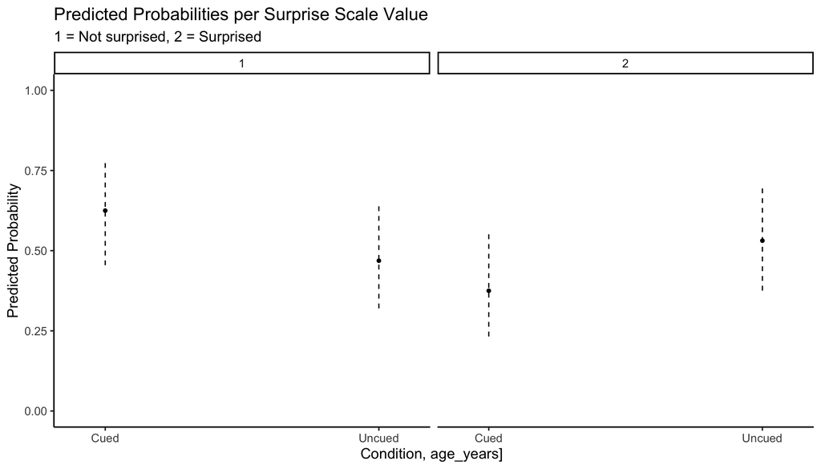

```r
plot(probs.memory_surprise) +
  ylim(0, 1) +
  labs(title = "Predicted Probabilities per Surprise Scale Value",
       subtitle = "1 = Not surprised, 2 = Surprised",
       x = "Condition, age_years] ",
       y = "Predicted Probability") +
  theme_classic(base_size = 18)
```

Just age:

```r
# logistic regression
summary(
  clm(
    # binary surprise is DV
    surprise_binary ~
      # intercept
      1 +
      # age as predictor
      age_bin,
    data = df.memory_analysis)
)
```

```
## formula: surprise_binary ~ 1 + age_bin
## data:    df.memory_analysis
##
##  link  threshold nobs logLik AIC   niter max.grad cond.H
##  logit flexible  64   -44.00 92.01 3(0)  1.10e-13 2.0e+03
##
## Coefficients:
##         Estimate Std. Error z value Pr(>|z|)
## age_bin  -0.1978     0.5084  -0.389    0.697
##
## Threshold coefficients:
##                         Estimate Std. Error z value
## Not surprised|Surprised  -0.7172     2.3390  -0.307
```

Age moderation:

```r
# logistic regression
fit.memory_surprise =
  clm(
    # binary surprise is DV
    surprise_binary ~
      # intercept
      1 +
      # condition as predictor
      condition * age_bin,
      # control for true performance
      # n_star_cards_selected,
    data = df.memory_analysis)

# print model outputs
fit.memory_surprise %>%
  summary()
```

```
## formula: surprise_binary ~ 1 + condition * age_bin
## data:    df.memory_analysis
##
##  link  threshold nobs logLik AIC   niter max.grad cond.H
##  logit flexible  64   -41.51 91.02 4(0)  1.28e-12 1.4e+04
##
## Coefficients:
##                         Estimate Std. Error z value Pr(>|z|)
## conditionUncued          -8.1356     4.8076  -1.692   0.0906 .
## age_bin                  -1.1838     0.7622  -1.553   0.1204
## conditionUncued:age_bin   1.9234     1.0518   1.829   0.0675 .
## ---
## Signif. codes:  0 '***' 0.001 '**' 0.01 '*' 0.05 '.' 0.1 ' ' 1
##
## Threshold coefficients:
##                         Estimate Std. Error z value
## Not surprised|Surprised   -4.889      3.476  -1.407
```

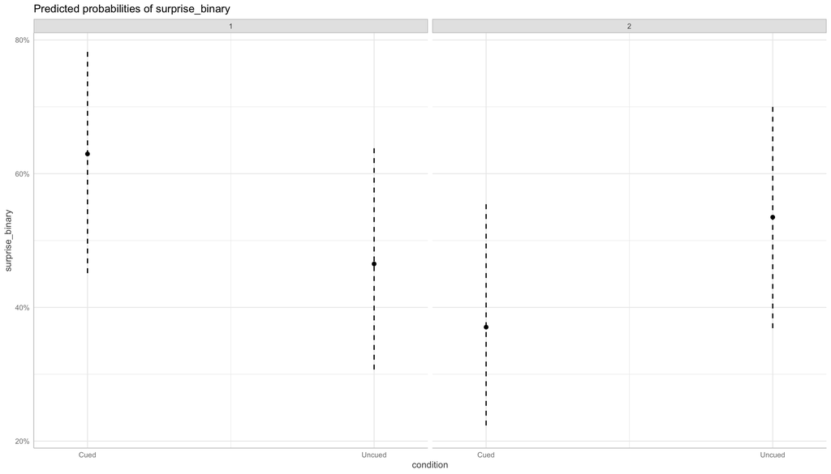

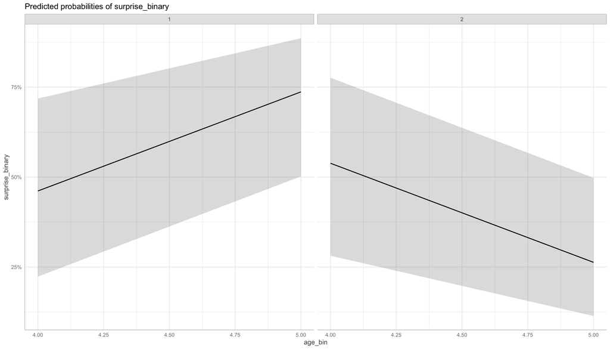

```r
# plot model predictions
probs.memory_surprise =
  ggpredict(fit.memory_surprise)

plot(probs.memory_surprise)
```

```r
# logistic regression
fit.memory_surprise =
  clm(
    # binary surprise is DV
    surprise_binary ~
      # intercept
      1 +
      # condition as predictor
      condition * age_years,
      # control for true performance
      # n_star_cards_selected,
    data = df.memory_analysis)

# print model outputs
fit.memory_surprise %>%
  summary()
```

```
## formula: surprise_binary ~ 1 + condition * age_years
## data:    df.memory_analysis
##
##  link  threshold nobs logLik AIC   niter max.grad cond.H
##  logit flexible  64   -41.70 91.39 4(0)  7.59e-13 1.4e+04
##
## Coefficients:
##                           Estimate Std. Error z value Pr(>|z|)
## conditionUncued            -7.2221     4.5782  -1.578   0.1147
## age_years                  -0.8919     0.6308  -1.414   0.1574
## conditionUncued:age_years   1.5706     0.9138   1.719   0.0856 .
## ---
## Signif. codes:  0 '***' 0.001 '**' 0.01 '*' 0.05 '.' 0.1 ' ' 1
##
## Threshold coefficients:
##                         Estimate Std. Error z value
## Not surprised|Surprised   -3.989      3.187  -1.252
```

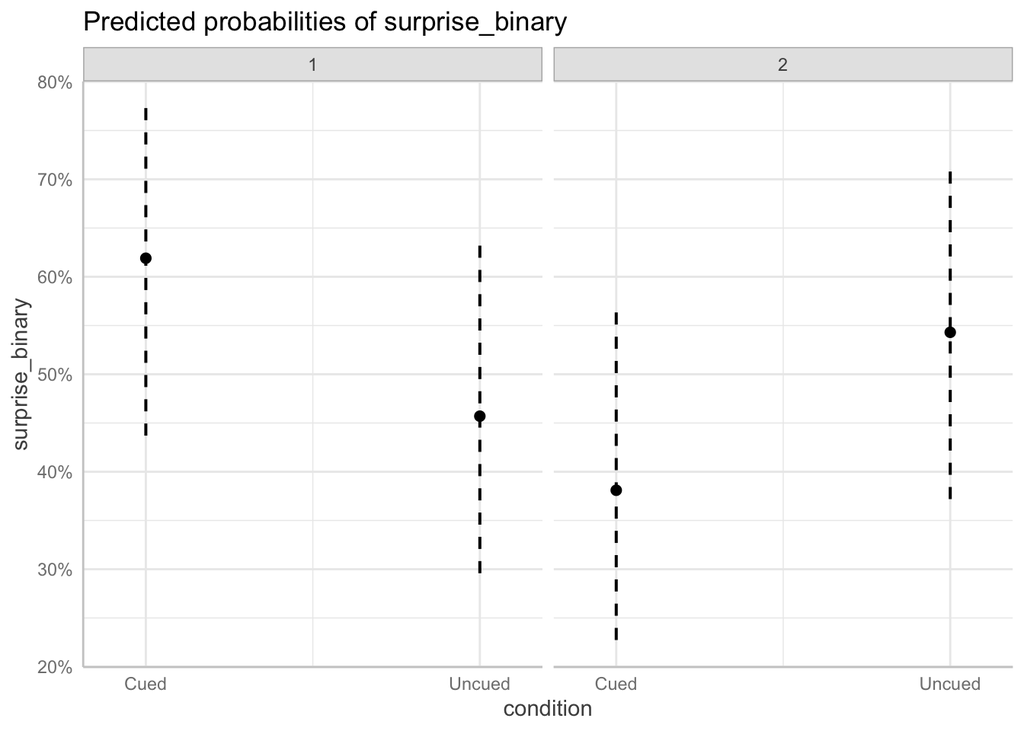

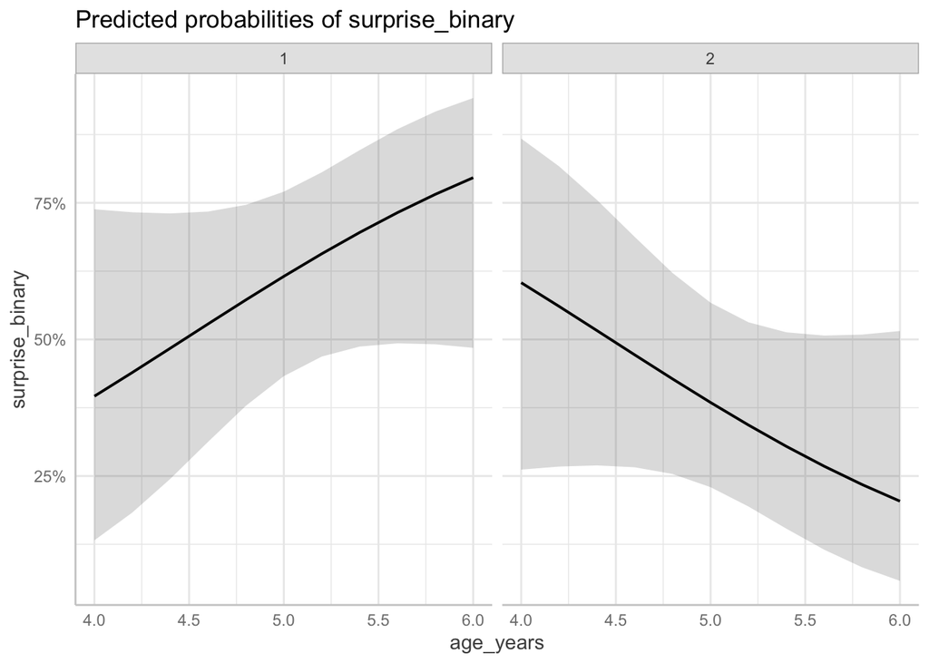

```r
# plot model predictions
probs.memory_surprise =
  ggpredict(fit.memory_surprise)

plot(probs.memory_surprise)
```

Subsetting for 4s:

```r
summary(
  clm(
    # binary surprise is DV
    surprise_binary ~
      # intercept
      1 +
      # condition as predictor
      condition,
      # control for true performance
      # n_star_cards_selected,
    data = df.memory_analysis %>%
      filter(age_bin == 4))
  )
```

```
## formula: surprise_binary ~ 1 + condition
## data:    df.memory_analysis %>% filter(age_bin == 4)
##
##  link  threshold nobs logLik AIC   niter max.grad cond.H
##  logit flexible  27   -18.53 41.07 2(0)  9.44e-07 7.0e+00
##
## Coefficients:
##                 Estimate Std. Error z value Pr(>|z|)
## conditionUncued  -0.4418     0.7754   -0.57    0.569
##
## Threshold coefficients:
##                         Estimate Std. Error z value
## Not surprised|Surprised  -0.1542     0.5563  -0.277
```

Subsetting for 5s:

```r
summary(
  clm(
    # binary surprise is DV
    surprise_binary ~
      # intercept
      1 +
      # condition as predictor
      condition,
      # control for true performance
      # n_star_cards_selected,
    data = df.memory_analysis %>%
      filter(age_bin == 5))
  )
```

```
## formula: surprise_binary ~ 1 + condition
## data:    df.memory_analysis %>% filter(age_bin == 5)
##
##  link  threshold nobs logLik AIC   niter max.grad cond.H
##  logit flexible  37   -22.98 49.96 4(0)  2.54e-13 7.4e+00
##
## Coefficients:
##                 Estimate Std. Error z value Pr(>|z|)
## conditionUncued   1.4816     0.7108   2.085   0.0371 *
## ---
## Signif. codes:  0 '***' 0.001 '**' 0.01 '*' 0.05 '.' 0.1 ' ' 1
##
## Threshold coefficients:
##                         Estimate Std. Error z value
## Not surprised|Surprised    1.030      0.521   1.976
```

Wilcox:

```r
wilcox.test(as.numeric(surprise_binary) ~ condition,
            data = df.memory_analysis)
```

```
##
##  Wilcoxon rank sum test with continuity correction
##
## data:  as.numeric(surprise_binary) by condition
## W = 432, p-value = 0.2158
## alternative hypothesis: true location shift is not equal to 0
```

### 7.2.5 Graded Surprise

Table:

```r
df.memory_analysis %>%
  count(condition, surprise_likert)
```

```
## # A tibble: 7 × 3
##   condition surprise_likert        n
##   <fct>     <ord>              <int>
## 1 Cued      Not surprised         20
## 2 Cued      Pretty surprised       4
## 3 Cued      Very surprised         8
## 4 Uncued    Not surprised         15
## 5 Uncued    A little surprised     5
## 6 Uncued    Pretty surprised       3
## 7 Uncued    Very surprised         9
```

```r
df.memory_analysis %>%
  mutate(surprise_likert_numerical =
           case_when(surprise_likert == "Not surprised" ~ 0,
                     surprise_likert == "A little surprised" ~ 1,
                     surprise_likert == "Pretty surprised" ~ 2,
                     surprise_likert == "Very surprised" ~ 3)) %>%
  group_by(condition) %>%
  summarise(mean = mean(surprise_likert_numerical),
            sd = sd(surprise_likert_numerical))
```

```
## # A tibble: 2 × 3
##   condition  mean    sd
##   <fct>     <dbl> <dbl>
## 1 Cued       1     1.34
## 2 Uncued     1.19  1.31
```

Regression:

```r
# logistic regression
fit.memory_surprise_graded =
  clm(
    # graded surprise is DV
    surprise_likert ~
      # intercept
      1 +
      # condition as predictor
      condition,
    data = df.memory_analysis)

# print model outputs
fit.memory_surprise_graded %>%
  summary()
```

```
## formula: surprise_likert ~ 1 + condition
## data:    df.memory_analysis
##
##  link  threshold nobs logLik AIC    niter max.grad cond.H
##  logit flexible  64   -71.54 151.09 6(1)  3.01e-10 6.6e+01
##
## Coefficients:
##                 Estimate Std. Error z value Pr(>|z|)
## conditionUncued    0.406      0.484   0.839    0.402
##
## Threshold coefficients:
##                                     Estimate Std. Error z value
## Not surprised|A little surprised      0.4057     0.3656   1.110
## A little surprised|Pretty surprised   0.7311     0.3731   1.960
## Pretty surprised|Very surprised       1.2361     0.3904   3.167
```

```r
# plot model predictions
probs.memory_surprise_graded =
  ggpredict(fit.memory_surprise_graded)

probs.memory_surprise_graded
```

```
## $condition
## # Predicted probabilities of surprise_likert
##
## surprise_likert: 1
##
## condition | Predicted |     95% CI
## ----------------------------------
## Cued      |      0.60 | 0.42, 0.75
## Uncued    |      0.50 | 0.34, 0.66
##
## surprise_likert: 2
##
## condition | Predicted |     95% CI
## ----------------------------------
## Cued      |      0.07 | 0.03, 0.17
## Uncued    |      0.08 | 0.03, 0.18
##
## surprise_likert: 3
##
## condition | Predicted |     95% CI
## ----------------------------------
## Cued      |      0.10 | 0.05, 0.20
## Uncued    |      0.12 | 0.06, 0.23
##
## surprise_likert: 4
##
## condition | Predicted |     95% CI
## ----------------------------------
## Cued      |      0.23 | 0.12, 0.38
## Uncued    |      0.30 | 0.18, 0.47
##
##
## attr(,"class")
## [1] "ggalleffects" "list"
## attr(,"model.name")
## [1] "fit.memory_surprise_graded"
```

Wilcox:

```r
wilcox.test(as.numeric(surprise_likert) ~ condition,
            data = df.memory_analysis)
```

```
##
##  Wilcoxon rank sum test with continuity correction
##
## data:  as.numeric(surprise_likert) by condition
## W = 456, p-value = 0.4094
## alternative hypothesis: true location shift is not equal to 0
```

Age as sole predictor:

```r
summary(
  clm(
    # binary surprise is DV
    surprise_likert ~
      # intercept
      1 +
      # age as predictor
      age_bin,
    data = df.memory_analysis))
```

```
## formula: surprise_likert ~ 1 + age_bin
## data:    df.memory_analysis
##
##  link  threshold nobs logLik AIC    niter max.grad cond.H
##  logit flexible  64   -71.89 151.79 6(1)  1.57e-09 5.5e+03
##
## Coefficients:
##         Estimate Std. Error z value Pr(>|z|)
## age_bin  0.03993    0.48211   0.083    0.934
##
## Threshold coefficients:
##                                     Estimate Std. Error z value
## Not surprised|A little surprised      0.3696     2.2069   0.167
## A little surprised|Pretty surprised   0.6924     2.2074   0.314
## Pretty surprised|Very surprised       1.1989     2.2163   0.541
```

Age moderation effect:

```r
# logistic regression
fit.memory_surprise_graded =
  clm(
    # binary surprise is DV
    surprise_likert ~
      # intercept
      1 +
      # condition as predictor
      condition * age_bin,
    data = df.memory_analysis)

# print model outputs
fit.memory_surprise_graded %>%
  summary()
```

```
## formula: surprise_likert ~ 1 + condition * age_bin
## data:    df.memory_analysis
##
##  link  threshold nobs logLik AIC    niter max.grad cond.H
##  logit flexible  64   -68.44 148.88 6(1)  1.93e-13 2.4e+04
##
## Coefficients:
##                         Estimate Std. Error z value Pr(>|z|)
## conditionUncued         -10.8282     4.6097  -2.349   0.0188 *
## age_bin                  -1.2855     0.7444  -1.727   0.0842 .
## conditionUncued:age_bin   2.4731     1.0118   2.444   0.0145 *
## ---
## Signif. codes:  0 '***' 0.001 '**' 0.01 '*' 0.05 '.' 0.1 ' ' 1
##
## Threshold coefficients:
##                                     Estimate Std. Error z value
## Not surprised|A little surprised      -5.477      3.388  -1.616
## A little surprised|Pretty surprised   -5.124      3.379  -1.516
## Pretty surprised|Very surprised       -4.561      3.366  -1.355
```

```r
# logistic regression
fit.memory_surprise_graded =
  clm(
    # binary surprise is DV
    surprise_likert ~
      # intercept
      1 +
      # condition as predictor
      condition * age_years,
    data = df.memory_analysis)

# print model outputs
fit.memory_surprise_graded %>%
  summary()
```

```
## formula: surprise_likert ~ 1 + condition * age_years
## data:    df.memory_analysis
##
##  link  threshold nobs logLik AIC    niter max.grad cond.H
##  logit flexible  64   -68.81 149.61 6(1)  2.07e-13 2.6e+04
##
## Coefficients:
##                           Estimate Std. Error z value Pr(>|z|)
## conditionUncued            -9.6504     4.4156  -2.186   0.0288 *
## age_years                  -1.0355     0.6311  -1.641   0.1008
## conditionUncued:age_years   2.0155     0.8813   2.287   0.0222 *
## ---
## Signif. codes:  0 '***' 0.001 '**' 0.01 '*' 0.05 '.' 0.1 ' ' 1
##
## Threshold coefficients:
##                                     Estimate Std. Error z value
## Not surprised|A little surprised      -4.843      3.187  -1.519
## A little surprised|Pretty surprised   -4.494      3.180  -1.413
## Pretty surprised|Very surprised       -3.941      3.168  -1.244
```

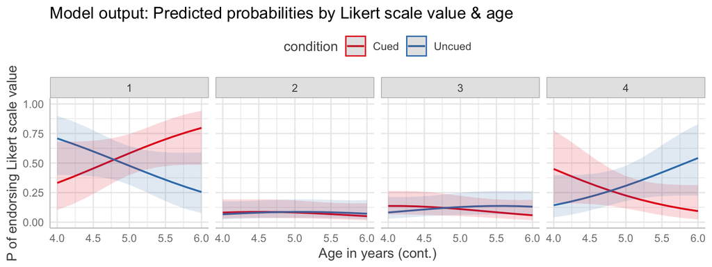

```r
# plot model predictions
probs.memory_surprise =
  ggpredict(fit.memory_surprise_graded,
            terms = c("age_years", "condition"))

plot(probs.memory_surprise,
     n_rows = 1) +
  scale_y_continuous(limits = c(0, 1),
                     breaks = c(0, .25, .5, .75, 1)) +
  labs(y = "P of endorsing Likert scale value",
       x = "Age in years (cont.)",
       title = "Model output: Predicted probabilities by Likert scale value & age") +
  theme(legend.position = "top")
```

Subsetting for 4s:

```r
summary(
  clm(
    # binary surprise is DV
    surprise_likert ~
      # intercept
      1 +
      # condition as predictor
      condition,
    data = df.memory_analysis %>%
      filter(age_bin == 4)))
```

```
## formula: surprise_likert ~ 1 + condition
## data:    df.memory_analysis %>% filter(age_bin == 4)
##
##  link  threshold nobs logLik AIC   niter max.grad cond.H
##  logit flexible  27   -31.47 70.93 6(0)  1.74e-12 3.4e+01
##
## Coefficients:
##                 Estimate Std. Error z value Pr(>|z|)
## conditionUncued  -1.0465     0.7536  -1.389    0.165
##
## Threshold coefficients:
##                                     Estimate Std. Error z value
## Not surprised|A little surprised     -0.5425     0.5868  -0.925
## A little surprised|Pretty surprised   0.1135     0.5785   0.196
## Pretty surprised|Very surprised       0.7392     0.5831   1.268
```

Subsetting for 5s:

```r
summary(
  clm(
    # binary surprise is DV
    surprise_likert ~
      # intercept
      1 +
      # condition as predictor
      condition,
    data = df.memory_analysis %>%
      filter(age_bin == 5))
  )
```

```
## formula: surprise_likert ~ 1 + condition
## data:    df.memory_analysis %>% filter(age_bin == 5)
##
##  link  threshold nobs logLik AIC   niter max.grad cond.H
##  logit flexible  37   -35.38 78.76 6(2)  4.56e-13 1.6e+02
##
## Coefficients:
##                 Estimate Std. Error z value Pr(>|z|)
## conditionUncued   1.4413     0.6844   2.106   0.0352 *
## ---
## Signif. codes:  0 '***' 0.001 '**' 0.01 '*' 0.05 '.' 0.1 ' ' 1
##
## Threshold coefficients:
##                                     Estimate Std. Error z value
## Not surprised|A little surprised      1.0160     0.5181   1.961
## A little surprised|Pretty surprised   1.1402     0.5250   2.172
## Pretty surprised|Very surprised       1.6670     0.5607   2.973
```

### 7.2.6 Robustness Tests

Correlation:

```r
cor.test(as.numeric(df.memory_analysis$prediction),
         as.numeric(df.memory_analysis$surprise_likert),
         method = "spearman")
```

```
##
##  Spearman's rank correlation rho
##
## data:  as.numeric(df.memory_analysis$prediction) and as.numeric(df.memory_analysis$surprise_likert)
## S = 44149, p-value = 0.9329
## alternative hypothesis: true rho is not equal to 0
## sample estimates:
##         rho
## -0.01073033
```

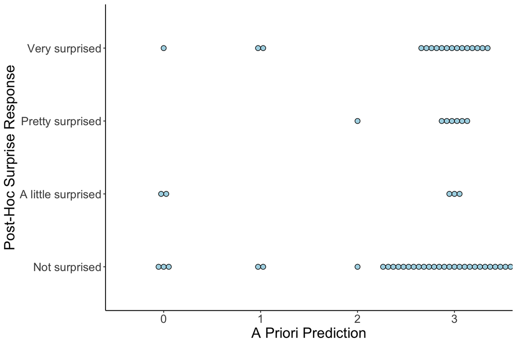

```r
plot.correlation =
  df.memory_analysis %>%
  ggplot(aes(x = prediction,
             y = surprise_likert)) +
  geom_dotplot(dotsize = .7,
               binaxis = "y",
               stackdir = "center",
               stackratio = 1,
               color = "black",
               fill = "lightblue") +
  # geom_point(size = 3,
  #            color = "black",
  #            position = position_jitter(width = .075,
  #                                       height = 0),
  #            alpha = .2) +
  labs(x = "A Priori Prediction",
       y = "Post-Hoc Surprise Response")

plot.correlation
```

```r
# ggsave((paste0(figures_dir, "memory/memory_correlation.png")),
#        plot = plot.correlation,
#        width = 9, height = 6, device = "png")
```

Subsetting for children who predicted 3 stars:

```r
df.robust_memory =
  df.memory_analysis %>%
  filter(prediction == 3)
```

```r
# logistic regression
fit.memory_surprise =
  clm(
    # binary surprise is DV
    surprise_binary ~
      # intercept
      1 +
      # condition as predictor
      condition,
    data = df.robust_memory)

# print model outputs
fit.memory_surprise %>%
  summary()
```

```
## formula: surprise_binary ~ 1 + condition
## data:    df.robust_memory
##
##  link  threshold nobs logLik AIC   niter max.grad cond.H
##  logit flexible  52   -34.93 73.87 3(0)  1.95e-10 6.0e+00
##
## Coefficients:
##                 Estimate Std. Error z value Pr(>|z|)
## conditionUncued   0.7115     0.5791   1.229    0.219
##
## Threshold coefficients:
##                         Estimate Std. Error z value
## Not surprised|Surprised   0.5108     0.3651   1.399
```

```r
# logistic regression
fit.memory_surprise =
  clm(
    # binary surprise is DV
    surprise_likert ~
      # intercept
      1 +
      # condition as predictor
      condition,
    data = df.robust_memory)

# print model outputs
fit.memory_surprise %>%
  summary()
```

```
## formula: surprise_likert ~ 1 + condition
## data:    df.robust_memory
##
##  link  threshold nobs logLik AIC    niter max.grad cond.H
##  logit flexible  52   -56.43 120.87 6(2)  1.16e-11 6.9e+01
##
## Coefficients:
##                 Estimate Std. Error z value Pr(>|z|)
## conditionUncued   0.4765     0.5433   0.877     0.38
##
## Threshold coefficients:
##                                     Estimate Std. Error z value
## Not surprised|A little surprised      0.4318     0.3657   1.181
## A little surprised|Pretty surprised   0.6728     0.3725   1.806
## Pretty surprised|Very surprised       1.2014     0.3947   3.043
```

Age effects for subset:

```r
df.robust_memory %>%
  group_by(condition, age_bin) %>%
  count()
```

```
## # A tibble: 4 × 3
## # Groups:   condition, age_bin [4]
##   condition age_bin     n
##   <fct>       <dbl> <int>
## 1 Cued            4    13
## 2 Cued            5    19
## 3 Uncued          4     8
## 4 Uncued          5    12
```

Age as sole predictor:

```r
summary(
  clm(
    # binary surprise is DV
    surprise_binary ~
      # intercept
      1 +
      # age as predictor
      age_bin,
    data = df.robust_memory)
  )
```

```
## formula: surprise_binary ~ 1 + age_bin
## data:    df.robust_memory
##
##  link  threshold nobs logLik AIC   niter max.grad cond.H
##  logit flexible  52   -35.22 74.45 3(0)  2.03e-10 2.0e+03
##
## Coefficients:
##         Estimate Std. Error z value Pr(>|z|)
## age_bin  -0.5548     0.5717   -0.97    0.332
##
## Threshold coefficients:
##                         Estimate Std. Error z value
## Not surprised|Surprised   -2.315      2.636  -0.878
```

```r
summary(
  clm(
    # binary surprise is DV
    surprise_likert ~
      # intercept
      1 +
      # age as predictor
      age_bin,
    data = df.robust_memory)
  )
```

```
## formula: surprise_likert ~ 1 + age_bin
## data:    df.robust_memory
##
##  link  threshold nobs logLik AIC    niter max.grad cond.H
##  logit flexible  52   -56.55 121.11 6(2)  1.12e-11 5.6e+03
##
## Coefficients:
##         Estimate Std. Error z value Pr(>|z|)
## age_bin  -0.3938     0.5408  -0.728    0.467
##
## Threshold coefficients:
##                                     Estimate Std. Error z value
## Not surprised|A little surprised      -1.568      2.482  -0.632
## A little surprised|Pretty surprised   -1.327      2.478  -0.535
## Pretty surprised|Very surprised       -0.796      2.478  -0.321
```

Moderation:

```r
# logistic regression
fit.memory_surprise =
  clm(
    # binary surprise is DV
    surprise_binary ~
      # intercept
      1 +
      # condition as predictor
      condition * age_bin,
    data = df.robust_memory)

# print model outputs
fit.memory_surprise %>%
  summary()
```

```
## formula: surprise_binary ~ 1 + condition * age_bin
## data:    df.robust_memory
##
##  link  threshold nobs logLik AIC   niter max.grad cond.H
##  logit flexible  52   -33.62 75.24 4(0)  1.23e-12 1.2e+04
##
## Coefficients:
##                         Estimate Std. Error z value Pr(>|z|)
## conditionUncued          -6.2351     5.4833  -1.137    0.255
## age_bin                  -1.1838     0.7622  -1.553    0.120
## conditionUncued:age_bin   1.5202     1.1932   1.274    0.203
##
## Threshold coefficients:
##                         Estimate Std. Error z value
## Not surprised|Surprised   -4.889      3.476  -1.407
```

```r
# logistic regression
fit.memory_surprise =
  clm(
    # binary surprise is DV
    surprise_likert ~
      # intercept
      1 +
      # condition as predictor
      condition * age_bin,
    data = df.robust_memory)

# print model outputs
fit.memory_surprise %>%
  summary()
```

```
## formula: surprise_likert ~ 1 + condition * age_bin
## data:    df.robust_memory
##
##  link  threshold nobs logLik AIC    niter max.grad cond.H
##  logit flexible  52   -54.58 121.15 6(2)  1.04e-11 1.8e+04
##
## Coefficients:
##                         Estimate Std. Error z value Pr(>|z|)
## conditionUncued          -8.6183     5.1345  -1.679   0.0932 .
## age_bin                  -1.2532     0.7422  -1.689   0.0913 .
## conditionUncued:age_bin   1.9961     1.1230   1.778   0.0755 .
## ---
## Signif. codes:  0 '***' 0.001 '**' 0.01 '*' 0.05 '.' 0.1 ' ' 1
##
## Threshold coefficients:
##                                     Estimate Std. Error z value
## Not surprised|A little surprised      -5.292      3.378  -1.567
## A little surprised|Pretty surprised   -5.036      3.370  -1.494
## Pretty surprised|Very surprised       -4.470      3.355  -1.333
```

Subsetting for 5s:

```r
# logistic regression
fit.memory_surprise =
  clm(
    # binary surprise is DV
    surprise_binary ~
      # intercept
      1 +
      # condition as predictor
      condition,
    data = df.robust_memory %>%
      filter(age_bin == 5))

# print model outputs
fit.memory_surprise %>%
  summary()
```

```
## formula: surprise_binary ~ 1 + condition
## data:    df.robust_memory %>% filter(age_bin == 5)
##
##  link  threshold nobs logLik AIC   niter max.grad cond.H
##  logit flexible  31   -19.10 42.20 4(0)  2.56e-13 6.3e+00
##
## Coefficients:
##                 Estimate Std. Error z value Pr(>|z|)
## conditionUncued   1.3661     0.7838   1.743   0.0813 .
## ---
## Signif. codes:  0 '***' 0.001 '**' 0.01 '*' 0.05 '.' 0.1 ' ' 1
##
## Threshold coefficients:
##                         Estimate Std. Error z value
## Not surprised|Surprised    1.030      0.521   1.976
```

```r
# logistic regression
fit.memory_surprise =
  clm(
    # binary surprise is DV
    surprise_likert ~
      # intercept
      1 +
      # condition as predictor
      condition,
    data = df.robust_memory %>%
      filter(age_bin == 5))

# print model outputs
fit.memory_surprise %>%
  summary()
```

```
## formula: surprise_likert ~ 1 + condition
## data:    df.robust_memory %>% filter(age_bin == 5)
##
##  link  threshold nobs logLik AIC   niter max.grad cond.H
##  logit flexible  31   -29.00 66.00 6(2)  2.00e-11 1.2e+02
##
## Coefficients:
##                 Estimate Std. Error z value Pr(>|z|)
## conditionUncued   1.3114     0.7509   1.746   0.0808 .
## ---
## Signif. codes:  0 '***' 0.001 '**' 0.01 '*' 0.05 '.' 0.1 ' ' 1
##
## Threshold coefficients:
##                                     Estimate Std. Error z value
## Not surprised|A little surprised      1.0149     0.5189   1.956
## A little surprised|Pretty surprised   1.1652     0.5289   2.203
## Pretty surprised|Very surprised       1.6577     0.5699   2.909
```

# 8 Non-3 Choosers

Chance-Based:

```r
df.chance %>%
  # exclude incomplete sessions
  filter(completed == T) %>%
  # exclude wrong control q answers
  filter(controlq == 1) %>%
  filter(no_marked_cards < 3) %>%
  count(prediction, surprise_binary)
```

```
## # A tibble: 5 × 3
##   prediction surprise_binary     n
##   <ord>      <ord>           <int>
## 1 1          Not surprised       1
## 2 1          Surprised           1
## 3 2          Not surprised       1
## 4 3          Not surprised       1
## 5 3          <NA>                1
```

```r
df.chance %>%
  # exclude incomplete sessions
  filter(completed == T) %>%
  # exclude wrong control q answers
  filter(controlq == 1) %>%
  filter(no_marked_cards < 3) %>%
  count(prediction, surprise_likert)
```

```
## # A tibble: 5 × 3
##   prediction surprise_likert        n
##   <ord>      <ord>              <int>
## 1 1          Not surprised          1
## 2 1          A little surprised     1
## 3 2          Not surprised          1
## 4 3          Not surprised          1
## 5 3          <NA>                   1
```

Memory:

```r
df.memory %>%
  # exclude incomplete sessions
  filter(completed == T) %>%
  # exclude wrong control q answers
  filter(controlq == 1) %>%
  filter(condition == "Cued",
         n_star_cards_selected < 3) %>%
  count(prediction, surprise_binary)
```

```
## # A tibble: 4 × 3
##   prediction surprise_binary     n
##   <ord>      <ord>           <int>
## 1 2          Not surprised       2
## 2 2          Surprised           1
## 3 3          Not surprised       1
## 4 3          Surprised           1
```

```r
df.memory %>%
  # exclude incomplete sessions
  filter(completed == T) %>%
  # exclude wrong control q answers
  filter(controlq == 1) %>%
  filter(condition == "Cued",
         n_star_cards_selected < 3) %>%
  count(prediction, surprise_likert)
```

```
## # A tibble: 4 × 3
##   prediction surprise_likert     n
##   <ord>      <ord>           <int>
## 1 2          Not surprised       2
## 2 2          Very surprised      1
## 3 3          Not surprised       1
## 4 3          Very surprised      1
```

# 9 Main Analyses Including Interference/Distraction Kids

*Chance-based*

```r
df.qualitative =
  df.chance %>%
  # exclude incomplete sessions (n = 6)
  filter(completed == T) %>%
  # exclude children who chose fewer than 3 marked cards in unsurprising (n = 5)
  filter(!(condition == "Cued" & no_marked_cards != 3))
# but keep kids who were distracted
```

Prediction:

```r
df.qualitative %>%
  count(condition, prediction)
```

```
## # A tibble: 5 × 3
##   condition prediction     n
##   <fct>     <ord>      <int>
## 1 Cued      3             30
## 2 Uncued    0              4
## 3 Uncued    1              2
## 4 Uncued    2              2
## 5 Uncued    3             22
```

Binary surprise:

```r
summary(
  clm(surprise_binary ~ condition,
      data = df.qualitative %>%
        filter(prediction == 3))
)
```

```
## formula: surprise_binary ~ condition
## data:    df.qualitative %>% filter(prediction == 3)
##
##  link  threshold nobs logLik AIC   niter max.grad cond.H
##  logit flexible  52   -34.29 72.58 3(0)  3.97e-08 6.0e+00
##
## Coefficients:
##                 Estimate Std. Error z value Pr(>|z|)
## conditionUncued   1.0304     0.5876   1.754   0.0795 .
## ---
## Signif. codes:  0 '***' 0.001 '**' 0.01 '*' 0.05 '.' 0.1 ' ' 1
##
## Threshold coefficients:
##                         Estimate Std. Error z value
## Not surprised|Surprised   0.2683     0.3684   0.728
```

Graded surprise:

```r
summary(
  clm(surprise_likert ~ condition,
      data = df.qualitative %>%
        filter(prediction == 3))
)
```

```
## formula: surprise_likert ~ condition
## data:    df.qualitative %>% filter(prediction == 3)
##
##  link  threshold nobs logLik AIC    niter max.grad cond.H
##  logit flexible  52   -59.12 126.24 9(1)  3.26e-11 4.9e+01
##
## Coefficients:
##                 Estimate Std. Error z value Pr(>|z|)
## conditionUncued   1.2298     0.5442    2.26   0.0238 *
## ---
## Signif. codes:  0 '***' 0.001 '**' 0.01 '*' 0.05 '.' 0.1 ' ' 1
##
## Threshold coefficients:
##                                     Estimate Std. Error z value
## Not surprised|A little surprised      0.3224     0.3582   0.900
## A little surprised|Pretty surprised   1.1113     0.3945   2.817
## Pretty surprised|Very surprised       1.4025     0.4151   3.379
```

*Memory*

```r
df.qualitative =
  df.memory %>%
  # filter participants too young (under 4; n = 1)
  filter(age_years > 4.00) %>%
  # exclude incomplete sessions (n = 4)
  filter(completed == T) %>%
  # exclude wrong control q answers (n = 7)
  filter(controlq == 1) %>%
  # exclude 'Expected Success' participants who chose fewer than 3 marked cards (n = 5)
  filter(!(condition == "Cued" &
             n_star_cards_selected != 3))
```

Prediction

```r
df.qualitative %>%
  count(condition, prediction)
```

```
## # A tibble: 7 × 3
##   condition prediction     n
##   <fct>     <ord>      <int>
## 1 Cued      1              2
## 2 Cued      2              1
## 3 Cued      3             43
## 4 Uncued    0              6
## 5 Uncued    1              5
## 6 Uncued    2              4
## 7 Uncued    3             29
```

Binary surprise:

```r
summary(
  clm(surprise_binary ~ condition,
      data = df.qualitative %>%
        filter(prediction == 3))
)
```

```
## formula: surprise_binary ~ condition
## data:    df.qualitative %>% filter(prediction == 3)
##
##  link  threshold nobs logLik AIC   niter max.grad cond.H
##  logit flexible  72   -47.22 98.43 3(0)  4.12e-08 6.2e+00
##
## Coefficients:
##                 Estimate Std. Error z value Pr(>|z|)
## conditionUncued   0.6592     0.4940   1.335    0.182
##
## Threshold coefficients:
##                         Estimate Std. Error z value
## Not surprised|Surprised   0.7282     0.3254   2.238
```

```r
summary(
  clm(surprise_binary ~ condition * age_bin,
      data = df.qualitative)
)
```

```
## formula: surprise_binary ~ condition * age_bin
## data:    df.qualitative
##
##  link  threshold nobs logLik AIC    niter max.grad cond.H
##  logit flexible  90   -57.17 122.33 4(0)  4.11e-09 1.4e+04
##
## Coefficients:
##                         Estimate Std. Error z value Pr(>|z|)
## conditionUncued          -5.7783     4.0739  -1.418   0.1561
## age_bin                  -1.0986     0.6667  -1.648   0.0994 .
## conditionUncued:age_bin   1.4663     0.9024   1.625   0.1042
## ---
## Signif. codes:  0 '***' 0.001 '**' 0.01 '*' 0.05 '.' 0.1 ' ' 1
##
## Threshold coefficients:
##                         Estimate Std. Error z value
## Not surprised|Surprised   -4.107      2.977   -1.38
```

Graded surprise:

```r
summary(
  clm(surprise_likert ~ condition,
      data = df.qualitative %>%
        filter(prediction == 3))
)
```

```
## formula: surprise_likert ~ condition
## data:    df.qualitative %>% filter(prediction == 3)
##
##  link  threshold nobs logLik AIC    niter max.grad cond.H
##  logit flexible  72   -73.30 154.59 6(2)  4.56e-12 9.1e+01
##
## Coefficients:
##                 Estimate Std. Error z value Pr(>|z|)
## conditionUncued   0.5557     0.4743   1.172    0.241
##
## Threshold coefficients:
##                                     Estimate Std. Error z value
## Not surprised|A little surprised      0.6917     0.3241   2.134
## A little surprised|Pretty surprised   0.8733     0.3300   2.647
## Pretty surprised|Very surprised       1.4986     0.3605   4.157
```

```r
summary(
  clm(surprise_likert ~ condition * age_bin,
      data = df.qualitative)
  )
```

```
## formula: surprise_likert ~ condition * age_bin
## data:    df.qualitative
##
##  link  threshold nobs logLik AIC    niter max.grad cond.H
##  logit flexible  90   -90.79 193.57 6(2)  3.31e-10 2.4e+04
##
## Coefficients:
##                         Estimate Std. Error z value Pr(>|z|)
## conditionUncued          -7.5404     3.9265  -1.920   0.0548 .
## age_bin                  -1.0840     0.6553  -1.654   0.0981 .
## conditionUncued:age_bin   1.8404     0.8740   2.106   0.0352 *
## ---
## Signif. codes:  0 '***' 0.001 '**' 0.01 '*' 0.05 '.' 0.1 ' ' 1
##
## Threshold coefficients:
##                                     Estimate Std. Error z value
## Not surprised|A little surprised      -4.081      2.918  -1.399
## A little surprised|Pretty surprised   -3.826      2.913  -1.313
## Pretty surprised|Very surprised       -3.244      2.908  -1.116
```